# Distributed Machine Learning

## Assignment 2

### Implementation and Performance Analysis of the Federated Averaging (FedAvg) Algorithm for Image Classification

**Course Code:** AIMLCZG515  
**Group Number:** 55

### Group 55 — Team Members

| S. No. | Name | ID Number |
| --- | --- | --- |
| 1 | Adurti Sai Venkatesh | 2024ac05968 |
| 2 | Akkireddy Pranith | 2024ac05473 |
| 3 | D. Mallikarjuna Reddy | 2024ac05653 |

**Technology Stack:** Python, TensorFlow/Keras, NumPy, Pandas, Matplotlib, scikit-learn, Kubeflow, NVIDIA GPU  
**Dataset:** MNIST Handwritten Digits  
**Federated Setup:** Five simulated clients, manual sample-weighted FedAvg, IID and Non-IID experiments

## Problem Definition and Experimental Setup

- Problem Statement, Objectives and Experimental Configuration

## Dataset Preparation and Exploratory Data Analysis

1. 1. Environment and GPU Validation
2. 2. Core Library Validation and Reproducibility Setup
3. 3. MNIST Dataset Loading
4. 4. Initial Visual Inspection of MNIST Samples
5. 5. Class Distribution Analysis
6. 6. Data Quality and Integrity Validation
7. 7. Pixel Intensity Distribution Analysis
8. 8. Image-Level Brightness and Foreground Analysis
9. 9. Class-Average Image Analysis
10. 10. Data Preprocessing and Normalization
11. 11. IID Client Data Partitioning
12. 12. IID Client Class Distribution Visualisation
13. 13. Non-IID Client Data Partitioning
14. 14. Non-IID Client Distribution and Heterogeneity Analysis
15. 15. Consolidated EDA Findings and Modelling Implications

## Model Development and Federated Learning Implementation

16. 16. Convolutional Neural Network Model Definition
17. 17. Local Client Training Function
18. 18. Manual Federated Averaging Function
19. 19. Global Model Evaluation Function
20. 20. Implementation Assumptions
21. 21. Federated Training Workflow Design
22. 22. Reference Model Initialisation
23. 23. Reproducible Experiment Initialisation

## Federated Training and Experimental Analysis

24. 24. Main FedAvg Experiment on IID Clients
25. 25. IID Global Performance Across Communication Rounds
26. 26. Experiment 1A: FedAvg with One Local Epoch
27. 27. Experiment 1B: FedAvg with Five Local Epochs
28. 28. Experiment 1: Comparison of Local Epoch Settings
29. 29. Experiment 2: FedAvg Training on Non-IID Clients
30. 30. Experiment 2: IID versus Non-IID Performance Comparison
31. 31. Final Global Model Class-Wise Evaluation

## Analysis, Conclusion and Validation

32. 32. Consolidated Experimental Findings
33. 33. Critical Analysis
34. 34. Limitations and Practical Considerations
35. 35. Conclusion
36. 36. Final Experiment Summary
37. 37. References
38. 38. Final Notebook Validation

# Problem Statement, Objectives and Experimental Configuration

## Problem Statement

A consortium of hospitals wishes to train a shared image-classification model without exchanging private local data. This notebook simulates that setting using five federated clients. Each client trains locally and shares only model parameters, which are aggregated centrally using a manually implemented Federated Averaging algorithm.

MNIST is used as the required image-classification dataset. The hospital scenario represents the privacy-preserving motivation; no real patient data are used.

## Objectives

1. Prepare MNIST and create five IID and five Non-IID client partitions.
2. Develop a compact CNN and train it locally at each simulated client.
3. Implement sample-weighted FedAvg manually without a federated-learning framework.
4. Run ten communication rounds and record client and global metrics.
5. Compare local epochs 1, 2, and 5.
6. Compare IID and Non-IID convergence, global accuracy, loss, and class-wise performance.
7. Critically analyze client heterogeneity and propose an improvement over standard FedAvg.

## Experimental Configuration

| Component | Setting |
| --- | --- |
| Clients | 5 |
| Communication rounds | 10 |
| Batch size | 32 |
| Main local epochs | 2 |
| Epoch comparison | 1, 2, 5 |
| Model | Lightweight CNN |
| Optimizer | Adam |
| Loss | Sparse categorical cross-entropy |
| Aggregation | Manual sample-count-weighted FedAvg |
| Evaluation | Central MNIST test set |

### 1. Environment and GPU Validation

This section validates the Python, TensorFlow, and hardware environment configured in Kubeflow. The purpose is to confirm that TensorFlow is installed correctly and that the allocated NVIDIA GPU is visible before dataset preparation and federated-learning experiments begin.

```python
import os
import warnings

os.environ["TF_CPP_MIN_LOG_LEVEL"] = "3"
warnings.filterwarnings("ignore")

import sys
import platform
import tensorflow as tf

print("=" * 80)
print("ENVIRONMENT VALIDATION")
print("=" * 80)

print(f"Python version      : {sys.version.split()[0]}")
print(f"Operating system    : {platform.system()} {platform.release()}")
print(f"TensorFlow version  : {tf.__version__}")

gpu_devices = tf.config.list_physical_devices("GPU")

print(f"GPU devices detected: {len(gpu_devices)}")

if gpu_devices:
    for index, device in enumerate(gpu_devices, start=1):
        print(f"GPU {index}              : {device}")
    print("\nEnvironment status  : TensorFlow GPU environment is ready.")
else:
    print("\nEnvironment status  : No GPU detected. TensorFlow will use the CPU.")
```

```
================================================================================
ENVIRONMENT VALIDATION
================================================================================
Python version      : 3.11.11
Operating system    : Linux 6.8.0-117-generic
TensorFlow version  : 2.17.1
GPU devices detected: 1
GPU 1              : PhysicalDevice(name='/physical_device:GPU:0', device_type='GPU')

Environment status  : TensorFlow GPU environment is ready.
```

🔝 Back to Table of Contents

### 2. Core Library Validation and Reproducibility Setup

This section imports the main libraries required for dataset handling, numerical computation, visualisation, model development, and result analysis. Random seeds are also fixed to make the dataset partitioning, model initialisation, and experimental results more reproducible across repeated executions.

```python
import os
import random
import numpy as np
import pandas as pd
import matplotlib.pyplot as plt
import tensorflow as tf

SEED = 42

os.environ["PYTHONHASHSEED"] = str(SEED)
random.seed(SEED)
np.random.seed(SEED)
tf.random.set_seed(SEED)

print("=" * 80)
print("LIBRARY AND REPRODUCIBILITY VALIDATION")
print("=" * 80)

print(f"NumPy version       : {np.__version__}")
print(f"Pandas version      : {pd.__version__}")
print(f"TensorFlow version  : {tf.__version__}")
print(f"Random seed         : {SEED}")
print("Matplotlib status   : Imported successfully")
print("\nValidation status   : Core libraries and reproducibility settings are ready.")
```

```
================================================================================
LIBRARY AND REPRODUCIBILITY VALIDATION
================================================================================
NumPy version       : 1.26.4
Pandas version      : 2.2.3
TensorFlow version  : 2.17.1
Random seed         : 42
Matplotlib status   : Imported successfully

Validation status   : Core libraries and reproducibility settings are ready.
```

🔝 Back to Table of Contents

### 3. MNIST Dataset Loading

The MNIST handwritten-digit dataset is loaded using the TensorFlow/Keras dataset utility. It contains 60,000 training images and 10,000 testing images across 10 digit classes. The training data will later be divided among five simulated federated clients, while the test data will be retained for evaluating the global model.

```python
# Load the MNIST dataset
(x_train, y_train), (x_test, y_test) = tf.keras.datasets.mnist.load_data()

print("=" * 80)
print("MNIST DATASET LOADING")
print("=" * 80)

print(f"Training images shape : {x_train.shape}")
print(f"Training labels shape : {y_train.shape}")
print(f"Testing images shape  : {x_test.shape}")
print(f"Testing labels shape  : {y_test.shape}")

print(f"\nNumber of classes     : {len(np.unique(y_train))}")
print(f"Training data type    : {x_train.dtype}")
print(f"Testing data type     : {x_test.dtype}")
print(f"Pixel value range     : {x_train.min()} to {x_train.max()}")

print("\nDataset status        : MNIST loaded successfully.")
```

```
================================================================================
MNIST DATASET LOADING
================================================================================
Training images shape : (60000, 28, 28)
Training labels shape : (60000,)
Testing images shape  : (10000, 28, 28)
Testing labels shape  : (10000,)

Number of classes     : 10
Training data type    : uint8
Testing data type     : uint8
Pixel value range     : 0 to 255

Dataset status        : MNIST loaded successfully.
```

🔝 Back to Table of Contents

### 4. Initial Visual Inspection of MNIST Samples

A selection of handwritten-digit images is displayed to verify the visual content, image orientation, background convention, and correspondence between images and labels. This qualitative inspection provides an initial understanding of the dataset before performing quantitative exploratory data analysis.

The displayed samples should not be interpreted as representative of the complete class distribution because they are taken from only a small subset of the training data. Class balance, pixel characteristics, data quality, and inter-class variation are analysed separately in subsequent sections.

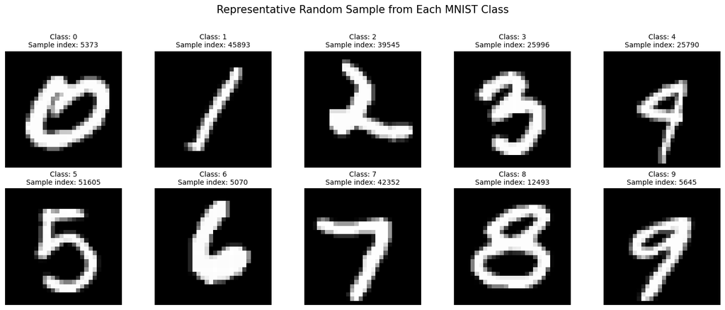

```
================================================================================
SAMPLE VISUALISATION SUMMARY
================================================================================
Class 0 | Index:  5373 | Minimum pixel:   0 | Maximum pixel: 255 | Mean intensity:  59.55 | Non-zero pixels: 237
Class 1 | Index: 45893 | Minimum pixel:   0 | Maximum pixel: 255 | Mean intensity:  17.50 | Non-zero pixels:  89
Class 2 | Index: 39545 | Minimum pixel:   0 | Maximum pixel: 255 | Mean intensity:  40.69 | Non-zero pixels: 168
Class 3 | Index: 25996 | Minimum pixel:   0 | Maximum pixel: 255 | Mean intensity:  46.52 | Non-zero pixels: 197
Class 4 | Index: 25790 | Minimum pixel:   0 | Maximum pixel: 255 | Mean intensity:  24.57 | Non-zero pixels: 109
Class 5 | Index: 51605 | Minimum pixel:   0 | Maximum pixel: 255 | Mean intensity:  37.01 | Non-zero pixels: 175
Class 6 | Index:  5070 | Minimum pixel:   0 | Maximum pixel: 255 | Mean intensity:  45.64 | Non-zero pixels: 179
Class 7 | Index: 42352 | Minimum pixel:   0 | Maximum pixel: 255 | Mean intensity:  35.72 | Non-zero pixels: 158
Class 8 | Index: 12493 | Minimum pixel:   0 | Maximum pixel: 255 | Mean intensity:  60.19 | Non-zero pixels: 265
Class 9 | Index:  5645 | Minimum pixel:   0 | Maximum pixel: 255 | Mean intensity:  37.87 | Non-zero pixels: 174
```

```python
# Select one reproducible random training image from each digit class
rng = np.random.default_rng(SEED)

selected_indices = []

for digit in range(10):
    digit_indices = np.where(y_train == digit)[0]
    selected_index = rng.choice(digit_indices)
    selected_indices.append(selected_index)

# Display one randomly selected image from each class
plt.figure(figsize=(15, 6))

for position, sample_index in enumerate(selected_indices):
    plt.subplot(2, 5, position + 1)
    plt.imshow(x_train[sample_index], cmap="gray", vmin=0, vmax=255)
    plt.title(
        f"Class: {y_train[sample_index]}\n"
        f"Sample index: {sample_index}",
        fontsize=10
    )
    plt.axis("off")

plt.suptitle(
    "Representative Random Sample from Each MNIST Class",
    fontsize=15,
    y=1.02
)
plt.tight_layout()
plt.show()

print("=" * 80)
print("SAMPLE VISUALISATION SUMMARY")
print("=" * 80)

for digit, sample_index in enumerate(selected_indices):
    image = x_train[sample_index]

    print(
        f"Class {digit} | "
        f"Index: {sample_index:5d} | "
        f"Minimum pixel: {image.min():3d} | "
        f"Maximum pixel: {image.max():3d} | "
        f"Mean intensity: {image.mean():6.2f} | "
        f"Non-zero pixels: {np.count_nonzero(image):3d}"
    )
```

🔝 Back to Table of Contents

### 5. Class Distribution Analysis

The frequency of each digit class is examined separately for the training and testing datasets. This analysis determines whether the dataset is balanced and whether any class is underrepresented.

Class imbalance can influence classification performance because classes with more samples may contribute more frequently to gradient updates. In federated learning, the original class distribution is also important because it forms the basis for creating IID and Non-IID client partitions.

```
====================================================================================================
MNIST CLASS DISTRIBUTION
====================================================================================================
```

|  | Digit | Training Samples | Training Percentage | Testing Samples | Testing Percentage | Train-Test Percentage Difference |
| --- | --- | --- | --- | --- | --- | --- |
| 0 | 0 | 5923 | 9.87% | 980 | 9.80% | 0.07% |
| 1 | 1 | 6742 | 11.24% | 1135 | 11.35% | 0.11% |
| 2 | 2 | 5958 | 9.93% | 1032 | 10.32% | 0.39% |
| 3 | 3 | 6131 | 10.22% | 1010 | 10.10% | 0.12% |
| 4 | 4 | 5842 | 9.74% | 982 | 9.82% | 0.08% |
| 5 | 5 | 5421 | 9.04% | 892 | 8.92% | 0.12% |
| 6 | 6 | 5918 | 9.86% | 958 | 9.58% | 0.28% |
| 7 | 7 | 6265 | 10.44% | 1028 | 10.28% | 0.16% |
| 8 | 8 | 5851 | 9.75% | 974 | 9.74% | 0.01% |
| 9 | 9 | 5949 | 9.92% | 1009 | 10.09% | 0.17% |

```
SUMMARY STATISTICS
----------------------------------------------------------------------------------------------------
Most frequent training class : 1 (6742 samples)
Least frequent training class: 5 (5421 samples)
Training imbalance ratio     : 1.2437
Most frequent testing class  : 1 (1135 samples)
Least frequent testing class : 5 (892 samples)
Testing imbalance ratio      : 1.2724
```

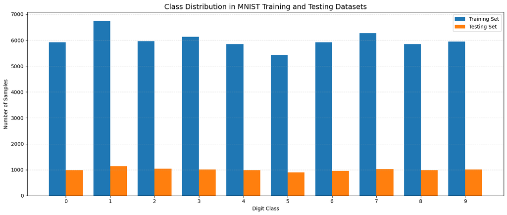

```python
# Calculate class frequencies for the training and testing datasets
train_class_counts = np.bincount(y_train, minlength=10)
test_class_counts = np.bincount(y_test, minlength=10)

class_distribution = pd.DataFrame({
    "Digit": np.arange(10),
    "Training Samples": train_class_counts,
    "Training Percentage": (train_class_counts / len(y_train)) * 100,
    "Testing Samples": test_class_counts,
    "Testing Percentage": (test_class_counts / len(y_test)) * 100
})

class_distribution["Train-Test Percentage Difference"] = (
    class_distribution["Training Percentage"]
    - class_distribution["Testing Percentage"]
).abs()

print("=" * 100)
print("MNIST CLASS DISTRIBUTION")
print("=" * 100)

display(
    class_distribution.style.format({
        "Training Percentage": "{:.2f}%",
        "Testing Percentage": "{:.2f}%",
        "Train-Test Percentage Difference": "{:.2f}%"
    })
)

print("\nSUMMARY STATISTICS")
print("-" * 100)

print(f"Most frequent training class : {train_class_counts.argmax()} "
      f"({train_class_counts.max()} samples)")

print(f"Least frequent training class: {train_class_counts.argmin()} "
      f"({train_class_counts.min()} samples)")

print(f"Training imbalance ratio     : "
      f"{train_class_counts.max() / train_class_counts.min():.4f}")

print(f"Most frequent testing class  : {test_class_counts.argmax()} "
      f"({test_class_counts.max()} samples)")

print(f"Least frequent testing class : {test_class_counts.argmin()} "
      f"({test_class_counts.min()} samples)")

print(f"Testing imbalance ratio      : "
      f"{test_class_counts.max() / test_class_counts.min():.4f}")

# Visualise training and testing class counts
x_positions = np.arange(10)
bar_width = 0.38

plt.figure(figsize=(14, 6))

plt.bar(
    x_positions - bar_width / 2,
    train_class_counts,
    width=bar_width,
    label="Training Set"
)

plt.bar(
    x_positions + bar_width / 2,
    test_class_counts,
    width=bar_width,
    label="Testing Set"
)

plt.title("Class Distribution in MNIST Training and Testing Datasets", fontsize=14)
plt.xlabel("Digit Class")
plt.ylabel("Number of Samples")
plt.xticks(x_positions)
plt.legend()
plt.grid(axis="y", linestyle="--", alpha=0.4)
plt.tight_layout()
plt.show()
```

🔝 Back to Table of Contents

### 6. Data Quality and Integrity Validation

This section performs structural and data-quality checks on the MNIST training and testing datasets. The objective is to verify that the arrays contain valid image dimensions, expected labels, finite values, valid pixel intensities, and no completely blank images.

These checks are important because invalid samples, unexpected labels, or corrupted pixel values could affect local client training and produce misleading federated-learning results.

```python
# Validate the structural integrity and quality of the MNIST dataset

expected_image_shape = (28, 28)
expected_classes = np.arange(10)

train_unique_labels = np.unique(y_train)
test_unique_labels = np.unique(y_test)

train_nan_count = np.isnan(x_train).sum()
test_nan_count = np.isnan(x_test).sum()

train_inf_count = np.isinf(x_train).sum()
test_inf_count = np.isinf(x_test).sum()

train_blank_images = np.sum(np.count_nonzero(x_train, axis=(1, 2)) == 0)
test_blank_images = np.sum(np.count_nonzero(x_test, axis=(1, 2)) == 0)

train_invalid_pixel_count = np.sum((x_train < 0) | (x_train > 255))
test_invalid_pixel_count = np.sum((x_test < 0) | (x_test > 255))

quality_checks = pd.DataFrame({
    "Validation Check": [
        "Training image shape",
        "Testing image shape",
        "Training labels",
        "Testing labels",
        "Training NaN values",
        "Testing NaN values",
        "Training infinite values",
        "Testing infinite values",
        "Training blank images",
        "Testing blank images",
        "Training invalid pixels",
        "Testing invalid pixels"
    ],
    "Observed Value": [
        str(x_train.shape[1:]),
        str(x_test.shape[1:]),
        str(train_unique_labels.tolist()),
        str(test_unique_labels.tolist()),
        int(train_nan_count),
        int(test_nan_count),
        int(train_inf_count),
        int(test_inf_count),
        int(train_blank_images),
        int(test_blank_images),
        int(train_invalid_pixel_count),
        int(test_invalid_pixel_count)
    ],
    "Expected Condition": [
        str(expected_image_shape),
        str(expected_image_shape),
        str(expected_classes.tolist()),
        str(expected_classes.tolist()),
        "0",
        "0",
        "0",
        "0",
        "0",
        "0",
        "0",
        "0"
    ]
})

quality_checks["Status"] = [
    "Pass" if x_train.shape[1:] == expected_image_shape else "Fail",
    "Pass" if x_test.shape[1:] == expected_image_shape else "Fail",
    "Pass" if np.array_equal(train_unique_labels, expected_classes) else "Fail",
    "Pass" if np.array_equal(test_unique_labels, expected_classes) else "Fail",
    "Pass" if train_nan_count == 0 else "Fail",
    "Pass" if test_nan_count == 0 else "Fail",
    "Pass" if train_inf_count == 0 else "Fail",
    "Pass" if test_inf_count == 0 else "Fail",
    "Pass" if train_blank_images == 0 else "Fail",
    "Pass" if test_blank_images == 0 else "Fail",
    "Pass" if train_invalid_pixel_count == 0 else "Fail",
    "Pass" if test_invalid_pixel_count == 0 else "Fail"
]

print("=" * 100)
print("MNIST DATA QUALITY AND INTEGRITY VALIDATION")
print("=" * 100)

display(quality_checks)

passed_checks = (quality_checks["Status"] == "Pass").sum()
total_checks = len(quality_checks)

print("\nSUMMARY")
print("-" * 100)
print(f"Checks passed         : {passed_checks}/{total_checks}")
print(f"Training samples      : {len(x_train)}")
print(f"Testing samples       : {len(x_test)}")
print(f"Image dimensions      : {x_train.shape[1]} x {x_train.shape[2]}")
print(f"Valid label range     : {train_unique_labels.min()} to {train_unique_labels.max()}")
print(f"Pixel intensity range : {x_train.min()} to {x_train.max()}")

if passed_checks == total_checks:
    print("\nValidation status     : All dataset integrity checks passed.")
else:
    print("\nValidation status     : One or more integrity checks failed.")
```

```
====================================================================================================
MNIST DATA QUALITY AND INTEGRITY VALIDATION
====================================================================================================
```

|  | Validation Check | Observed Value | Expected Condition | Status |
| --- | --- | --- | --- | --- |
| 0 | Training image shape | (28, 28) | (28, 28) | Pass |
| 1 | Testing image shape | (28, 28) | (28, 28) | Pass |
| 2 | Training labels | [0, 1, 2, 3, 4, 5, 6, 7, 8, 9] | [0, 1, 2, 3, 4, 5, 6, 7, 8, 9] | Pass |
| 3 | Testing labels | [0, 1, 2, 3, 4, 5, 6, 7, 8, 9] | [0, 1, 2, 3, 4, 5, 6, 7, 8, 9] | Pass |
| 4 | Training NaN values | 0 | 0 | Pass |
| 5 | Testing NaN values | 0 | 0 | Pass |
| 6 | Training infinite values | 0 | 0 | Pass |
| 7 | Testing infinite values | 0 | 0 | Pass |
| 8 | Training blank images | 0 | 0 | Pass |
| 9 | Testing blank images | 0 | 0 | Pass |
| 10 | Training invalid pixels | 0 | 0 | Pass |
| 11 | Testing invalid pixels | 0 | 0 | Pass |

```
SUMMARY
----------------------------------------------------------------------------------------------------
Checks passed         : 12/12
Training samples      : 60000
Testing samples       : 10000
Image dimensions      : 28 x 28
Valid label range     : 0 to 9
Pixel intensity range : 0 to 255

Validation status     : All dataset integrity checks passed.
```

#### Observations

- All **12/12** structural and integrity checks passed: valid 28 × 28 image shape, expected labels 0–9, no NaN or infinite values, no blank images, and no out-of-range pixels.
- Performing these checks before client partitioning ensures that every simulated client receives structurally valid data and that later IID/Non-IID comparisons are not affected by avoidable data-quality defects.

🔝 Back to Table of Contents

### 7. Pixel Intensity Distribution Analysis

The distribution of grayscale pixel intensities is analysed to understand the relationship between image background and handwritten foreground strokes.

MNIST images contain a large black background area and a smaller number of non-zero pixels representing the handwritten digit. Examining the pixel distribution helps determine the extent of sparsity, the prevalence of background pixels, and whether normalization is required before model training.

The analysis is performed separately for the training and testing datasets to verify that both datasets exhibit similar low-level image characteristics.

```
====================================================================================================
PIXEL INTENSITY DISTRIBUTION SUMMARY
====================================================================================================
```

|  | Metric | Training Set | Testing Set |
| --- | --- | --- | --- |
| 0 | Total pixels | 47,040,000.0000 | 7,840,000.0000 |
| 1 | Zero-valued pixels | 38,045,844.0000 | 6,328,781.0000 |
| 2 | Non-zero pixels | 8,994,156.0000 | 1,511,219.0000 |
| 3 | Zero-pixel percentage | 80.8798 | 80.7242 |
| 4 | Non-zero pixel percentage | 19.1202 | 19.2758 |
| 5 | Mean pixel intensity | 33.3184 | 33.7912 |
| 6 | Median pixel intensity | 0.0000 | 0.0000 |
| 7 | Standard deviation | 78.5675 | 79.1725 |
| 8 | Minimum intensity | 0.0000 | 0.0000 |
| 9 | Maximum intensity | 255.0000 | 255.0000 |

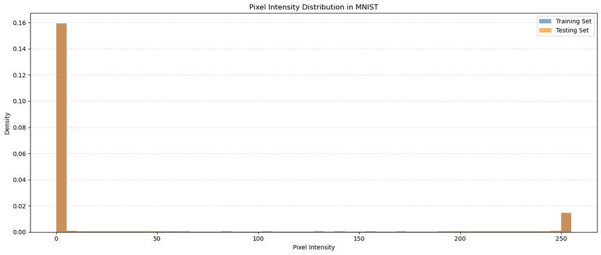

```
ADDITIONAL SUMMARY
----------------------------------------------------------------------------------------------------
Training background proportion : 80.88%
Testing background proportion  : 80.72%
Training foreground proportion : 19.12%
Testing foreground proportion  : 19.28%
```

```python
# Analyse pixel intensity distributions in the training and testing datasets

train_pixels = x_train.reshape(-1)
test_pixels = x_test.reshape(-1)

train_zero_pixels = np.sum(train_pixels == 0)
test_zero_pixels = np.sum(test_pixels == 0)

train_nonzero_pixels = np.sum(train_pixels > 0)
test_nonzero_pixels = np.sum(test_pixels > 0)

train_total_pixels = train_pixels.size
test_total_pixels = test_pixels.size

pixel_summary = pd.DataFrame({
    "Metric": [
        "Total pixels",
        "Zero-valued pixels",
        "Non-zero pixels",
        "Zero-pixel percentage",
        "Non-zero pixel percentage",
        "Mean pixel intensity",
        "Median pixel intensity",
        "Standard deviation",
        "Minimum intensity",
        "Maximum intensity"
    ],
    "Training Set": [
        train_total_pixels,
        train_zero_pixels,
        train_nonzero_pixels,
        (train_zero_pixels / train_total_pixels) * 100,
        (train_nonzero_pixels / train_total_pixels) * 100,
        train_pixels.mean(),
        np.median(train_pixels),
        train_pixels.std(),
        train_pixels.min(),
        train_pixels.max()
    ],
    "Testing Set": [
        test_total_pixels,
        test_zero_pixels,
        test_nonzero_pixels,
        (test_zero_pixels / test_total_pixels) * 100,
        (test_nonzero_pixels / test_total_pixels) * 100,
        test_pixels.mean(),
        np.median(test_pixels),
        test_pixels.std(),
        test_pixels.min(),
        test_pixels.max()
    ]
})

print("=" * 100)
print("PIXEL INTENSITY DISTRIBUTION SUMMARY")
print("=" * 100)

display(
    pixel_summary.style.format({
        "Training Set": "{:,.4f}",
        "Testing Set": "{:,.4f}"
    })
)

# Plot pixel intensity histograms
plt.figure(figsize=(14, 6))

plt.hist(
    train_pixels,
    bins=50,
    density=True,
    alpha=0.6,
    label="Training Set"
)

plt.hist(
    test_pixels,
    bins=50,
    density=True,
    alpha=0.6,
    label="Testing Set"
)

plt.title("Pixel Intensity Distribution in MNIST")
plt.xlabel("Pixel Intensity")
plt.ylabel("Density")
plt.legend()
plt.grid(axis="y", linestyle="--", alpha=0.4)
plt.tight_layout()
plt.show()

print("\nADDITIONAL SUMMARY")
print("-" * 100)

print(
    f"Training background proportion : "
    f"{(train_zero_pixels / train_total_pixels) * 100:.2f}%"
)

print(
    f"Testing background proportion  : "
    f"{(test_zero_pixels / test_total_pixels) * 100:.2f}%"
)

print(
    f"Training foreground proportion : "
    f"{(train_nonzero_pixels / train_total_pixels) * 100:.2f}%"
)

print(
    f"Testing foreground proportion  : "
    f"{(test_nonzero_pixels / test_total_pixels) * 100:.2f}%"
)
```

#### Observations

- Approximately **80.88%** of training pixels and **80.72%** of testing pixels are zero-valued background; the remaining **19.12%** and **19.28%** represent foreground stroke information.
- Training and testing intensity profiles are closely aligned, so no low-level pixel-distribution shift is evident.
- A fixed **0–255 to 0–1 rescaling** is used because the source range is known, it preserves the zero background, and it retains the relative grayscale contrast needed by the CNN.

🔝 Back to Table of Contents

### 8. Image-Level Brightness and Foreground Analysis

This section examines image-level characteristics rather than aggregating all pixels together. For every image, the mean pixel intensity and number of non-zero foreground pixels are calculated.

The purpose is to understand how much handwriting area and brightness vary across samples and digit classes. These characteristics provide insight into intra-class variability and help identify whether certain classes consistently occupy more or less image area.

```
====================================================================================================
IMAGE-LEVEL BRIGHTNESS AND FOREGROUND SUMMARY
====================================================================================================
```

|  | Metric | Training Set | Testing Set |
| --- | --- | --- | --- |
| 0 | Mean image intensity | 33.32 | 33.79 |
| 1 | Median image intensity | 32.48 | 32.99 |
| 2 | Minimum image intensity | 6.49 | 7.17 |
| 3 | Maximum image intensity | 101.38 | 83.43 |
| 4 | Mean non-zero pixels per image | 149.90 | 151.12 |
| 5 | Median non-zero pixels per image | 150.00 | 151.00 |
| 6 | Minimum non-zero pixels per image | 34.00 | 44.00 |
| 7 | Maximum non-zero pixels per image | 351.00 | 311.00 |

```
CLASS-WISE IMAGE STATISTICS
----------------------------------------------------------------------------------------------------
```

|  | Digit | Train Mean Intensity | Test Mean Intensity | Train Mean Non-zero Pixels | Test Mean Non-zero Pixels |
| --- | --- | --- | --- | --- | --- |
| 0 | 0 | 44.22 | 43.94 | 191.97 | 190.54 |
| 1 | 1 | 19.38 | 19.57 | 85.85 | 86.22 |
| 2 | 2 | 37.99 | 38.30 | 168.81 | 169.06 |
| 3 | 3 | 36.09 | 36.54 | 163.34 | 164.15 |
| 4 | 4 | 30.95 | 31.28 | 141.81 | 142.58 |
| 5 | 5 | 32.83 | 33.67 | 152.33 | 154.64 |
| 6 | 6 | 35.01 | 36.61 | 156.93 | 162.65 |
| 7 | 7 | 29.20 | 29.30 | 131.40 | 131.41 |
| 8 | 8 | 38.29 | 39.05 | 173.32 | 175.61 |
| 9 | 9 | 31.26 | 31.94 | 143.03 | 145.17 |

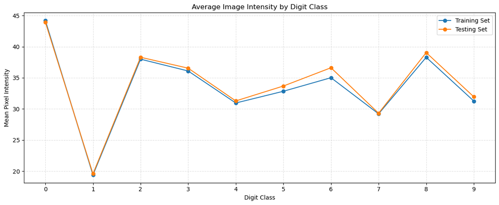

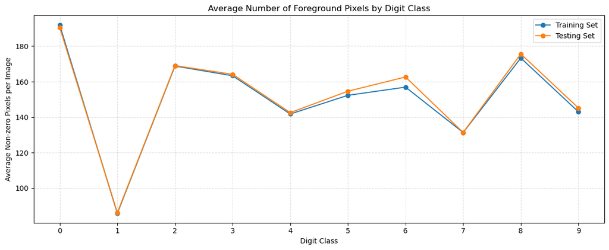

```python
# Calculate image-level brightness and foreground statistics

train_mean_intensity = x_train.mean(axis=(1, 2))
test_mean_intensity = x_test.mean(axis=(1, 2))

train_nonzero_count = np.count_nonzero(x_train, axis=(1, 2))
test_nonzero_count = np.count_nonzero(x_test, axis=(1, 2))

image_level_summary = pd.DataFrame({
    "Metric": [
        "Mean image intensity",
        "Median image intensity",
        "Minimum image intensity",
        "Maximum image intensity",
        "Mean non-zero pixels per image",
        "Median non-zero pixels per image",
        "Minimum non-zero pixels per image",
        "Maximum non-zero pixels per image"
    ],
    "Training Set": [
        train_mean_intensity.mean(),
        np.median(train_mean_intensity),
        train_mean_intensity.min(),
        train_mean_intensity.max(),
        train_nonzero_count.mean(),
        np.median(train_nonzero_count),
        train_nonzero_count.min(),
        train_nonzero_count.max()
    ],
    "Testing Set": [
        test_mean_intensity.mean(),
        np.median(test_mean_intensity),
        test_mean_intensity.min(),
        test_mean_intensity.max(),
        test_nonzero_count.mean(),
        np.median(test_nonzero_count),
        test_nonzero_count.min(),
        test_nonzero_count.max()
    ]
})

print("=" * 100)
print("IMAGE-LEVEL BRIGHTNESS AND FOREGROUND SUMMARY")
print("=" * 100)

display(
    image_level_summary.style.format({
        "Training Set": "{:.2f}",
        "Testing Set": "{:.2f}"
    })
)

# Class-wise image statistics
class_image_statistics = []

for digit in range(10):
    train_mask = y_train == digit
    test_mask = y_test == digit

    class_image_statistics.append({
        "Digit": digit,
        "Train Mean Intensity": train_mean_intensity[train_mask].mean(),
        "Test Mean Intensity": test_mean_intensity[test_mask].mean(),
        "Train Mean Non-zero Pixels": train_nonzero_count[train_mask].mean(),
        "Test Mean Non-zero Pixels": test_nonzero_count[test_mask].mean()
    })

class_image_statistics = pd.DataFrame(class_image_statistics)

print("\nCLASS-WISE IMAGE STATISTICS")
print("-" * 100)

display(
    class_image_statistics.style.format({
        "Train Mean Intensity": "{:.2f}",
        "Test Mean Intensity": "{:.2f}",
        "Train Mean Non-zero Pixels": "{:.2f}",
        "Test Mean Non-zero Pixels": "{:.2f}"
    })
)

# Plot mean intensity by class
plt.figure(figsize=(12, 5))

plt.plot(
    class_image_statistics["Digit"],
    class_image_statistics["Train Mean Intensity"],
    marker="o",
    label="Training Set"
)

plt.plot(
    class_image_statistics["Digit"],
    class_image_statistics["Test Mean Intensity"],
    marker="o",
    label="Testing Set"
)

plt.title("Average Image Intensity by Digit Class")
plt.xlabel("Digit Class")
plt.ylabel("Mean Pixel Intensity")
plt.xticks(range(10))
plt.legend()
plt.grid(linestyle="--", alpha=0.4)
plt.tight_layout()
plt.show()

# Plot average foreground pixels by class
plt.figure(figsize=(12, 5))

plt.plot(
    class_image_statistics["Digit"],
    class_image_statistics["Train Mean Non-zero Pixels"],
    marker="o",
    label="Training Set"
)

plt.plot(
    class_image_statistics["Digit"],
    class_image_statistics["Test Mean Non-zero Pixels"],
    marker="o",
    label="Testing Set"
)

plt.title("Average Number of Foreground Pixels by Digit Class")
plt.xlabel("Digit Class")
plt.ylabel("Average Non-zero Pixels per Image")
plt.xticks(range(10))
plt.legend()
plt.grid(linestyle="--", alpha=0.4)
plt.tight_layout()
plt.show()
```

#### Observations

- Mean image intensity and foreground-pixel coverage vary by class: digits such as **0** and **8** occupy more of the canvas, while digit **1** has a much smaller visual footprint.
- Training and testing statistics follow closely matching class-wise patterns, supporting the use of the common test set for global evaluation.
- These spatial differences support the selection of a CNN, which can learn local stroke and shape patterns directly.

🔝 Back to Table of Contents

### 9. Class-Average Image Analysis

Average images are computed for each digit class by taking the pixel-wise mean of all training images belonging to that class.

These average representations reveal the dominant spatial structure learned from thousands of handwritten samples. They help identify the common stroke patterns, central alignment, class-level variability, and areas where different classes may visually overlap.

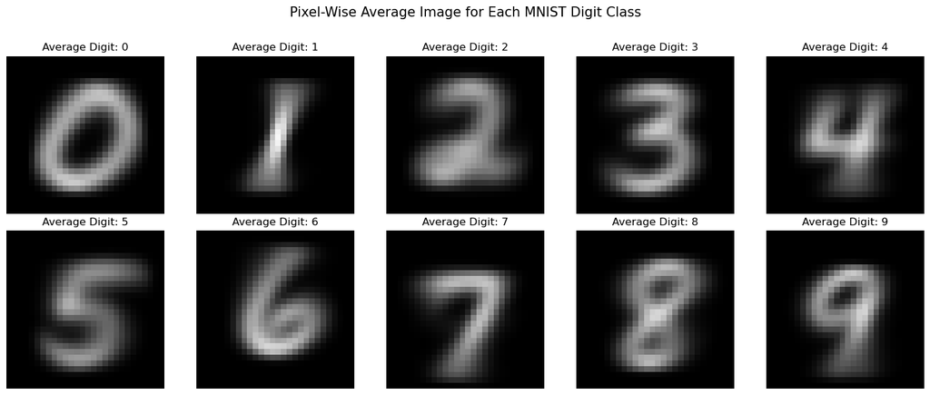

```
====================================================================================================
CLASS-AVERAGE IMAGE STATISTICS
====================================================================================================
```

|  | Digit | Average Image Mean Intensity | Average Image Maximum Intensity | Pixels Above Intensity 25 | Pixels Above Intensity 50 | Pixels Above Intensity 100 |
| --- | --- | --- | --- | --- | --- | --- |
| 0 | 0 | 44.22 | 201.60 | 303 | 256 | 175 |
| 1 | 1 | 19.38 | 246.30 | 147 | 107 | 60 |
| 2 | 2 | 37.99 | 176.20 | 302 | 230 | 139 |
| 3 | 3 | 36.09 | 198.77 | 276 | 209 | 123 |
| 4 | 4 | 30.95 | 214.73 | 262 | 183 | 92 |
| 5 | 5 | 32.83 | 174.31 | 290 | 222 | 99 |
| 6 | 6 | 35.01 | 213.41 | 263 | 206 | 132 |
| 7 | 7 | 29.20 | 195.89 | 228 | 168 | 95 |
| 8 | 8 | 38.29 | 212.69 | 281 | 233 | 143 |
| 9 | 9 | 31.26 | 209.80 | 242 | 187 | 107 |

```python
# Compute and display the average image for each digit class

class_average_images = []

for digit in range(10):
    class_images = x_train[y_train == digit]
    average_image = class_images.mean(axis=0)
    class_average_images.append(average_image)

plt.figure(figsize=(15, 6))

for digit, average_image in enumerate(class_average_images):
    plt.subplot(2, 5, digit + 1)
    plt.imshow(average_image, cmap="gray", vmin=0, vmax=255)
    plt.title(f"Average Digit: {digit}")
    plt.axis("off")

plt.suptitle(
    "Pixel-Wise Average Image for Each MNIST Digit Class",
    fontsize=15,
    y=1.02
)
plt.tight_layout()
plt.show()

# Calculate class-average concentration statistics
average_image_statistics = []

for digit, average_image in enumerate(class_average_images):
    average_image_statistics.append({
        "Digit": digit,
        "Average Image Mean Intensity": average_image.mean(),
        "Average Image Maximum Intensity": average_image.max(),
        "Pixels Above Intensity 25": np.sum(average_image > 25),
        "Pixels Above Intensity 50": np.sum(average_image > 50),
        "Pixels Above Intensity 100": np.sum(average_image > 100)
    })

average_image_statistics = pd.DataFrame(average_image_statistics)

print("=" * 100)
print("CLASS-AVERAGE IMAGE STATISTICS")
print("=" * 100)

display(
    average_image_statistics.style.format({
        "Average Image Mean Intensity": "{:.2f}",
        "Average Image Maximum Intensity": "{:.2f}"
    })
)
```

#### Observations

- The class-average images preserve clear digit shapes, confirming that MNIST samples are generally centered and consistently aligned.
- Digit **0** has the largest average foreground footprint, while digit **1** has the smallest.
- Digit **1** shows the highest peak average intensity, indicating strong alignment of its central stroke across samples.
- More complex digits such as **2, 3, 5, and 8** show broader spatial patterns because of greater handwriting variation.
- These differences support the use of a CNN, which can learn spatial stroke patterns more effectively than relying only on overall intensity.

🔝 Back to Table of Contents

### 10. Data Preprocessing and Normalization

The MNIST images are converted from unsigned 8-bit integers to 32-bit floating-point values and normalized from the original range of 0–255 to 0–1.

A channel dimension is also added so that every image has the shape 28 × 28 × 1, which is required by the convolutional neural network. The same preprocessing is applied to both the training and testing datasets to maintain consistency during local client training and global model evaluation.

```python
# Preserve the original arrays and create preprocessed copies
x_train_processed = x_train.astype("float32") / 255.0
x_test_processed = x_test.astype("float32") / 255.0

# Add the grayscale channel dimension required by Conv2D
x_train_processed = np.expand_dims(x_train_processed, axis=-1)
x_test_processed = np.expand_dims(x_test_processed, axis=-1)

print("=" * 100)
print("DATA PREPROCESSING VALIDATION")
print("=" * 100)

print(f"Original training shape     : {x_train.shape}")
print(f"Processed training shape    : {x_train_processed.shape}")
print(f"Original testing shape      : {x_test.shape}")
print(f"Processed testing shape     : {x_test_processed.shape}")

print(f"\nOriginal training dtype     : {x_train.dtype}")
print(f"Processed training dtype    : {x_train_processed.dtype}")
print(f"Original testing dtype      : {x_test.dtype}")
print(f"Processed testing dtype     : {x_test_processed.dtype}")

print(
    f"\nProcessed training range    : "
    f"{x_train_processed.min():.4f} to {x_train_processed.max():.4f}"
)

print(
    f"Processed testing range     : "
    f"{x_test_processed.min():.4f} to {x_test_processed.max():.4f}"
)

print(f"Training labels shape       : {y_train.shape}")
print(f"Testing labels shape        : {y_test.shape}")

shape_valid = (
    x_train_processed.shape == (60000, 28, 28, 1)
    and x_test_processed.shape == (10000, 28, 28, 1)
)

range_valid = (
    x_train_processed.min() >= 0.0
    and x_train_processed.max() <= 1.0
    and x_test_processed.min() >= 0.0
    and x_test_processed.max() <= 1.0
)

dtype_valid = (
    x_train_processed.dtype == np.float32
    and x_test_processed.dtype == np.float32
)

print("\nVALIDATION RESULTS")
print("-" * 100)
print(f"Image shape validation     : {'Pass' if shape_valid else 'Fail'}")
print(f"Pixel range validation     : {'Pass' if range_valid else 'Fail'}")
print(f"Data type validation       : {'Pass' if dtype_valid else 'Fail'}")

if shape_valid and range_valid and dtype_valid:
    print("\nPreprocessing status       : Training and testing data are ready.")
else:
    print("\nPreprocessing status       : One or more validation checks failed.")
```

```
====================================================================================================
DATA PREPROCESSING VALIDATION
====================================================================================================
Original training shape     : (60000, 28, 28)
Processed training shape    : (60000, 28, 28, 1)
Original testing shape      : (10000, 28, 28)
Processed testing shape     : (10000, 28, 28, 1)

Original training dtype     : uint8
Processed training dtype    : float32
Original testing dtype      : uint8
Processed testing dtype     : float32

Processed training range    : 0.0000 to 1.0000
Processed testing range     : 0.0000 to 1.0000
Training labels shape       : (60000,)
Testing labels shape        : (10000,)

VALIDATION RESULTS
----------------------------------------------------------------------------------------------------
Image shape validation     : Pass
Pixel range validation     : Pass
Data type validation       : Pass

Preprocessing status       : Training and testing data are ready.
```

#### Observations

- Images were converted to `float32`, normalized to **[0, 1]**, and reshaped to **(28, 28, 1)** for `Conv2D`.
- The same preprocessing is applied to every client and to the test set, ensuring consistent local training and comparable model updates during FedAvg aggregation.

🔝 Back to Table of Contents

### 11. IID Client Data Partitioning

The preprocessed MNIST training dataset is divided among five simulated federated clients using an Independent and Identically Distributed (IID) strategy.

The training indices are shuffled using a fixed random seed and then split equally across the clients. This allows each client to receive a representative mixture of all ten digit classes while preserving reproducibility.

```python
# Create five IID client partitions

NUM_CLIENTS = 5

rng = np.random.default_rng(SEED)

all_indices = np.arange(len(x_train_processed))
shuffled_indices = rng.permutation(all_indices)

iid_index_splits = np.array_split(shuffled_indices, NUM_CLIENTS)

iid_clients = {}

for client_id, client_indices in enumerate(iid_index_splits, start=1):
    iid_clients[f"Client_{client_id}"] = {
        "x": x_train_processed[client_indices],
        "y": y_train[client_indices],
        "indices": client_indices
    }

print("=" * 100)
print("IID CLIENT PARTITIONING SUMMARY")
print("=" * 100)

iid_partition_summary = []

for client_name, client_data in iid_clients.items():
    class_counts = np.bincount(client_data["y"], minlength=10)

    iid_partition_summary.append({
        "Client": client_name,
        "Total Samples": len(client_data["y"]),
        **{f"Digit {digit}": class_counts[digit] for digit in range(10)}
    })

iid_partition_summary = pd.DataFrame(iid_partition_summary)

display(iid_partition_summary)

total_assigned_samples = sum(
    len(client_data["y"])
    for client_data in iid_clients.values()
)

unique_assigned_indices = np.unique(
    np.concatenate([
        client_data["indices"]
        for client_data in iid_clients.values()
    ])
)

print("\nVALIDATION RESULTS")
print("-" * 100)
print(f"Number of clients          : {len(iid_clients)}")
print(f"Samples per client         : {[len(data['y']) for data in iid_clients.values()]}")
print(f"Total assigned samples     : {total_assigned_samples}")
print(f"Unique assigned samples    : {len(unique_assigned_indices)}")
print(f"Original training samples  : {len(x_train_processed)}")

partition_valid = (
    len(iid_clients) == NUM_CLIENTS
    and total_assigned_samples == len(x_train_processed)
    and len(unique_assigned_indices) == len(x_train_processed)
)

print(
    f"\nIID partition status       : "
    f"{'Valid' if partition_valid else 'Invalid'}"
)
```

```
====================================================================================================
IID CLIENT PARTITIONING SUMMARY
====================================================================================================
```

|  | Client | Total Samples | Digit 0 | Digit 1 | Digit 2 | Digit 3 | Digit 4 | Digit 5 | Digit 6 | Digit 7 | Digit 8 | Digit 9 |
| --- | --- | --- | --- | --- | --- | --- | --- | --- | --- | --- | --- | --- |
| 0 | Client_1 | 12000 | 1211 | 1369 | 1189 | 1267 | 1168 | 1063 | 1179 | 1222 | 1152 | 1180 |
| 1 | Client_2 | 12000 | 1153 | 1331 | 1208 | 1249 | 1190 | 1137 | 1164 | 1219 | 1163 | 1186 |
| 2 | Client_3 | 12000 | 1145 | 1334 | 1166 | 1196 | 1195 | 1110 | 1195 | 1235 | 1227 | 1197 |
| 3 | Client_4 | 12000 | 1202 | 1333 | 1203 | 1215 | 1155 | 1046 | 1196 | 1326 | 1151 | 1173 |
| 4 | Client_5 | 12000 | 1212 | 1375 | 1192 | 1204 | 1134 | 1065 | 1184 | 1263 | 1158 | 1213 |

```
VALIDATION RESULTS
----------------------------------------------------------------------------------------------------
Number of clients          : 5
Samples per client         : [12000, 12000, 12000, 12000, 12000]
Total assigned samples     : 60000
Unique assigned samples    : 60000
Original training samples  : 60000

IID partition status       : Valid
```

#### Observations

- The IID strategy created exactly five clients with **12,000 samples each**, assigning all **60,000** training samples once with no overlap or omission.
- Per-class client counts remain close to the global distribution, ranging from **1,046 to 1,375** samples across the observed client–digit combinations.
- This balanced partition provides a valid IID baseline for the later comparison with the deliberately skewed Non-IID setting.

🔝 Back to Table of Contents

### 12. IID Client Class Distribution Visualisation

The class distribution of each IID client is visualised to verify that all clients contain a similar proportion of the ten digit classes.

A correctly constructed IID partition should preserve the overall MNIST class pattern across clients, with only small differences caused by random sampling.

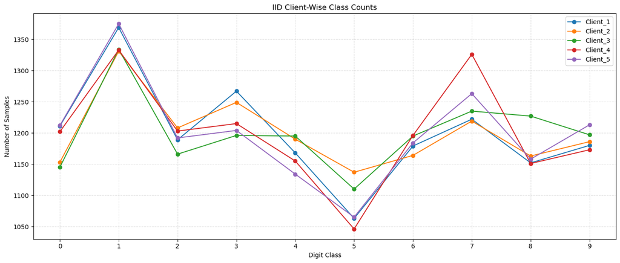

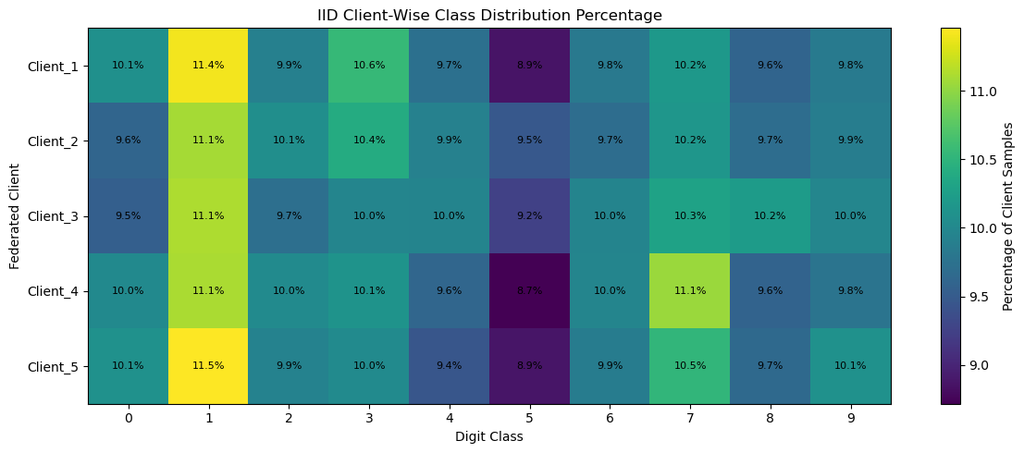

```
====================================================================================================
IID CLIENT DISTRIBUTION VARIATION
====================================================================================================
```

|  | Digit | Minimum Client Count | Maximum Client Count | Count Range | Mean Client Percentage | Percentage Standard Deviation |
| --- | --- | --- | --- | --- | --- | --- |
| 0 | 0 | 1145 | 1212 | 67 | 9.87% | 0.245% |
| 1 | 1 | 1331 | 1375 | 44 | 11.24% | 0.162% |
| 2 | 2 | 1166 | 1208 | 42 | 9.93% | 0.121% |
| 3 | 3 | 1196 | 1267 | 71 | 10.22% | 0.227% |
| 4 | 4 | 1134 | 1195 | 61 | 9.74% | 0.188% |
| 5 | 5 | 1046 | 1137 | 91 | 9.04% | 0.282% |
| 6 | 6 | 1164 | 1196 | 32 | 9.86% | 0.098% |
| 7 | 7 | 1219 | 1326 | 107 | 10.44% | 0.331% |
| 8 | 8 | 1151 | 1227 | 76 | 9.75% | 0.239% |
| 9 | 9 | 1173 | 1213 | 40 | 9.92% | 0.117% |

```python
# Prepare class-count matrix for IID clients
iid_class_count_matrix = np.array([
    np.bincount(client_data["y"], minlength=10)
    for client_data in iid_clients.values()
])

iid_class_percentage_matrix = (
    iid_class_count_matrix
    / iid_class_count_matrix.sum(axis=1, keepdims=True)
) * 100

client_names = list(iid_clients.keys())
digit_labels = np.arange(10)

# Plot absolute class counts
plt.figure(figsize=(14, 6))

for client_index, client_name in enumerate(client_names):
    plt.plot(
        digit_labels,
        iid_class_count_matrix[client_index],
        marker="o",
        label=client_name
    )

plt.title("IID Client-Wise Class Counts")
plt.xlabel("Digit Class")
plt.ylabel("Number of Samples")
plt.xticks(digit_labels)
plt.legend()
plt.grid(linestyle="--", alpha=0.4)
plt.tight_layout()
plt.show()

# Plot class percentages as a heatmap
plt.figure(figsize=(12, 5))

heatmap = plt.imshow(
    iid_class_percentage_matrix,
    aspect="auto"
)

plt.title("IID Client-Wise Class Distribution Percentage")
plt.xlabel("Digit Class")
plt.ylabel("Federated Client")
plt.xticks(digit_labels)
plt.yticks(np.arange(NUM_CLIENTS), client_names)

for row in range(NUM_CLIENTS):
    for column in range(10):
        plt.text(
            column,
            row,
            f"{iid_class_percentage_matrix[row, column]:.1f}%",
            ha="center",
            va="center",
            fontsize=8
        )

plt.colorbar(heatmap, label="Percentage of Client Samples")
plt.tight_layout()
plt.show()

# Quantify variation between IID clients
iid_class_variation = pd.DataFrame({
    "Digit": digit_labels,
    "Minimum Client Count": iid_class_count_matrix.min(axis=0),
    "Maximum Client Count": iid_class_count_matrix.max(axis=0),
    "Count Range": (
        iid_class_count_matrix.max(axis=0)
        - iid_class_count_matrix.min(axis=0)
    ),
    "Mean Client Percentage": iid_class_percentage_matrix.mean(axis=0),
    "Percentage Standard Deviation": iid_class_percentage_matrix.std(axis=0)
})

print("=" * 100)
print("IID CLIENT DISTRIBUTION VARIATION")
print("=" * 100)

display(
    iid_class_variation.style.format({
        "Mean Client Percentage": "{:.2f}%",
        "Percentage Standard Deviation": "{:.3f}%"
    })
)
```

#### Observations

- The five client profiles nearly overlap, and each client retains approximately the same class proportions as the complete MNIST training set.
- Percentage standard deviation across clients remains below **0.34 percentage points** for every digit, confirming low inter-client distribution variation.
- The IID baseline is therefore suitable for isolating the effect of label heterogeneity in the Non-IID experiment.

🔝 Back to Table of Contents

### 13. Non-IID Client Data Partitioning

A Non-IID client distribution is created using a label-shard strategy. The training samples are first ordered by digit label and then divided into multiple shards. Each client receives two shards, resulting in client datasets dominated by a limited subset of classes.

This partition simulates realistic federated-learning environments in which different clients hold data with different label distributions.

```python
# Create five Non-IID client partitions using label shards

NUM_SHARDS = 10
SHARDS_PER_CLIENT = 2

# Sort all training indices by class label
sorted_indices = np.argsort(y_train)

# Divide the label-sorted indices into equal shards
non_iid_shards = np.array_split(sorted_indices, NUM_SHARDS)

# Shuffle shard assignments reproducibly
rng = np.random.default_rng(SEED)
shard_order = rng.permutation(NUM_SHARDS)

non_iid_clients = {}

for client_index in range(NUM_CLIENTS):
    assigned_shard_ids = shard_order[
        client_index * SHARDS_PER_CLIENT:
        (client_index + 1) * SHARDS_PER_CLIENT
    ]

    client_indices = np.concatenate([
        non_iid_shards[shard_id]
        for shard_id in assigned_shard_ids
    ])

    non_iid_clients[f"Client_{client_index + 1}"] = {
        "x": x_train_processed[client_indices],
        "y": y_train[client_indices],
        "indices": client_indices,
        "shards": assigned_shard_ids
    }

print("=" * 100)
print("NON-IID CLIENT PARTITIONING SUMMARY")
print("=" * 100)

non_iid_partition_summary = []

for client_name, client_data in non_iid_clients.items():
    class_counts = np.bincount(client_data["y"], minlength=10)

    non_iid_partition_summary.append({
        "Client": client_name,
        "Assigned Shards": client_data["shards"].tolist(),
        "Total Samples": len(client_data["y"]),
        **{f"Digit {digit}": class_counts[digit] for digit in range(10)}
    })

non_iid_partition_summary = pd.DataFrame(non_iid_partition_summary)

display(non_iid_partition_summary)

total_assigned_samples = sum(
    len(client_data["y"])
    for client_data in non_iid_clients.values()
)

unique_assigned_indices = np.unique(
    np.concatenate([
        client_data["indices"]
        for client_data in non_iid_clients.values()
    ])
)

print("\nVALIDATION RESULTS")
print("-" * 100)
print(f"Number of clients          : {len(non_iid_clients)}")
print(f"Number of shards           : {NUM_SHARDS}")
print(f"Shards per client          : {SHARDS_PER_CLIENT}")
print(f"Samples per client         : {[len(data['y']) for data in non_iid_clients.values()]}")
print(f"Total assigned samples     : {total_assigned_samples}")
print(f"Unique assigned samples    : {len(unique_assigned_indices)}")
print(f"Original training samples  : {len(x_train_processed)}")

partition_valid = (
    len(non_iid_clients) == NUM_CLIENTS
    and total_assigned_samples == len(x_train_processed)
    and len(unique_assigned_indices) == len(x_train_processed)
)

print(
    f"\nNon-IID partition status   : "
    f"{'Valid' if partition_valid else 'Invalid'}"
)
```

```
====================================================================================================
NON-IID CLIENT PARTITIONING SUMMARY
====================================================================================================
```

|  | Client | Assigned Shards | Total Samples | Digit 0 | Digit 1 | Digit 2 | Digit 3 | Digit 4 | Digit 5 | Digit 6 | Digit 7 | Digit 8 | Digit 9 |
| --- | --- | --- | --- | --- | --- | --- | --- | --- | --- | --- | --- | --- | --- |
| 0 | Client_1 | [5, 6] | 12000 | 0 | 0 | 0 | 0 | 596 | 5421 | 5918 | 65 | 0 | 0 |
| 1 | Client_2 | [0, 7] | 12000 | 5923 | 77 | 0 | 0 | 0 | 0 | 0 | 6000 | 0 | 0 |
| 2 | Client_3 | [3, 2] | 12000 | 0 | 665 | 5958 | 5377 | 0 | 0 | 0 | 0 | 0 | 0 |
| 3 | Client_4 | [4, 9] | 12000 | 0 | 0 | 0 | 754 | 5246 | 0 | 0 | 0 | 51 | 5949 |
| 4 | Client_5 | [1, 8] | 12000 | 0 | 6000 | 0 | 0 | 0 | 0 | 0 | 200 | 5800 | 0 |

```
VALIDATION RESULTS
----------------------------------------------------------------------------------------------------
Number of clients          : 5
Number of shards           : 10
Shards per client          : 2
Samples per client         : [12000, 12000, 12000, 12000, 12000]
Total assigned samples     : 60000
Unique assigned samples    : 60000
Original training samples  : 60000

Non-IID partition status   : Valid
```

#### Observations

- The label-shard assignment creates clear client specialization. For example, Client 1 is concentrated around digits **5 and 6**, while Client 5 is concentrated around digits **1 and 8**.
- Every client still contains exactly **12,000 samples**, so the IID and Non-IID experiments differ in label distribution rather than total client data volume.
- Because shard boundaries can cross class boundaries, each client contains three or four labels even though only two shards are assigned.

🔝 Back to Table of Contents

### 14. Non-IID Client Distribution and Heterogeneity Analysis

The class distribution of each Non-IID client is visualised and quantified. Unlike the IID setting, each client contains samples concentrated in only a limited subset of digit classes.

This analysis confirms the degree of statistical heterogeneity introduced by the shard-based partitioning and establishes the basis for comparing FedAvg performance under IID and Non-IID conditions.

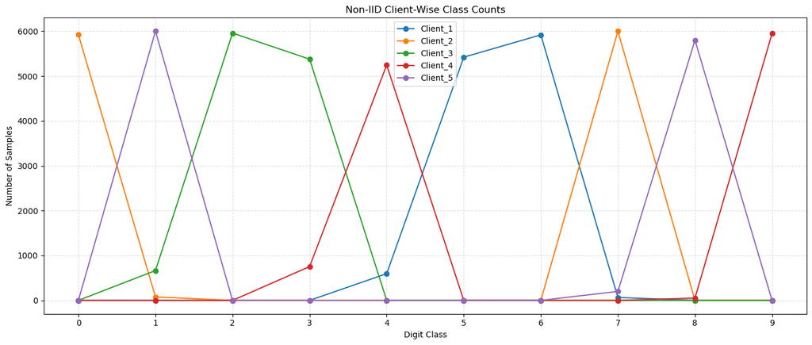

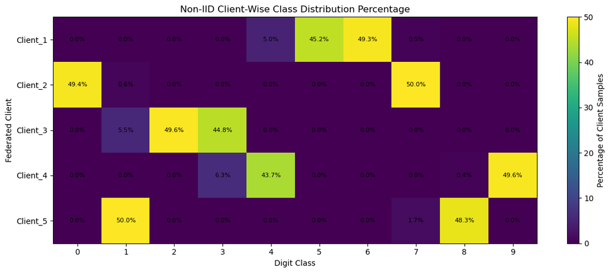

```
====================================================================================================
NON-IID CLIENT HETEROGENEITY SUMMARY
====================================================================================================
```

|  | Client | Dominant Class | Dominant Class Percentage | Classes Present | Classes with at least 10% Share |
| --- | --- | --- | --- | --- | --- |
| 0 | Client_1 | 6 | 49.32% | 4 | 2 |
| 1 | Client_2 | 7 | 50.00% | 3 | 2 |
| 2 | Client_3 | 2 | 49.65% | 3 | 2 |
| 3 | Client_4 | 9 | 49.58% | 4 | 2 |
| 4 | Client_5 | 1 | 50.00% | 3 | 2 |

```
OVERALL HETEROGENEITY METRICS
----------------------------------------------------------------------------------------------------
Average dominant-class share : 49.71%
Minimum classes per client   : 3
Maximum classes per client   : 4
```

```python
# Prepare Non-IID class-count and percentage matrices
non_iid_class_count_matrix = np.array([
    np.bincount(client_data["y"], minlength=10)
    for client_data in non_iid_clients.values()
])

non_iid_class_percentage_matrix = (
    non_iid_class_count_matrix
    / non_iid_class_count_matrix.sum(axis=1, keepdims=True)
) * 100

client_names = list(non_iid_clients.keys())
digit_labels = np.arange(10)

# Plot absolute class counts
plt.figure(figsize=(14, 6))

for client_index, client_name in enumerate(client_names):
    plt.plot(
        digit_labels,
        non_iid_class_count_matrix[client_index],
        marker="o",
        label=client_name
    )

plt.title("Non-IID Client-Wise Class Counts")
plt.xlabel("Digit Class")
plt.ylabel("Number of Samples")
plt.xticks(digit_labels)
plt.legend()
plt.grid(linestyle="--", alpha=0.4)
plt.tight_layout()
plt.show()

# Plot class percentages as a heatmap
plt.figure(figsize=(12, 5))

heatmap = plt.imshow(
    non_iid_class_percentage_matrix,
    aspect="auto"
)

plt.title("Non-IID Client-Wise Class Distribution Percentage")
plt.xlabel("Digit Class")
plt.ylabel("Federated Client")
plt.xticks(digit_labels)
plt.yticks(np.arange(NUM_CLIENTS), client_names)

for row in range(NUM_CLIENTS):
    for column in range(10):
        plt.text(
            column,
            row,
            f"{non_iid_class_percentage_matrix[row, column]:.1f}%",
            ha="center",
            va="center",
            fontsize=8
        )

plt.colorbar(heatmap, label="Percentage of Client Samples")
plt.tight_layout()
plt.show()

# Quantify client-level heterogeneity
non_iid_heterogeneity_summary = []

for client_index, client_name in enumerate(client_names):
    percentages = non_iid_class_percentage_matrix[client_index]

    dominant_class = int(np.argmax(percentages))
    dominant_percentage = percentages[dominant_class]

    active_classes = int(np.sum(non_iid_class_count_matrix[client_index] > 0))
    major_classes = int(np.sum(percentages >= 10))

    non_iid_heterogeneity_summary.append({
        "Client": client_name,
        "Dominant Class": dominant_class,
        "Dominant Class Percentage": dominant_percentage,
        "Classes Present": active_classes,
        "Classes with at least 10% Share": major_classes
    })

non_iid_heterogeneity_summary = pd.DataFrame(
    non_iid_heterogeneity_summary
)

print("=" * 100)
print("NON-IID CLIENT HETEROGENEITY SUMMARY")
print("=" * 100)

display(
    non_iid_heterogeneity_summary.style.format({
        "Dominant Class Percentage": "{:.2f}%"
    })
)

print("\nOVERALL HETEROGENEITY METRICS")
print("-" * 100)

print(
    f"Average dominant-class share : "
    f"{non_iid_heterogeneity_summary['Dominant Class Percentage'].mean():.2f}%"
)

print(
    f"Minimum classes per client   : "
    f"{non_iid_heterogeneity_summary['Classes Present'].min()}"
)

print(
    f"Maximum classes per client   : "
    f"{non_iid_heterogeneity_summary['Classes Present'].max()}"
)
```

#### Observations

- The average dominant-class share is **49.71%**, and each client contains only **3–4** of the ten classes.
- Only two classes per client contribute at least 10% of local samples, confirming a strongly heterogeneous Non-IID partition.
- This controlled skew is sufficient to examine client specialization and its effect on FedAvg convergence.

🔝 Back to Table of Contents

### 15. Consolidated EDA Findings and Modelling Implications

The exploratory analysis confirmed that MNIST contains 60,000 training images and 10,000 testing images, with valid 28 × 28 grayscale inputs and ten digit classes. All dataset-integrity checks passed, with no missing values, infinite values, blank images, invalid labels, or out-of-range pixels.

The dataset is reasonably balanced, with class proportions close to 10% in both training and testing sets. Training and testing data also show similar pixel-intensity, foreground-density, and class-wise image characteristics, indicating no meaningful distribution mismatch between the two splits.

Approximately 81% of all pixels represent the black background, while about 19% contain handwritten foreground information. Class-average images preserve recognizable digit structures, confirming consistent centering while also showing natural handwriting variation.

The IID partition distributed all 60,000 samples equally across five clients, with similar class proportions for every client. In contrast, the Non-IID shard-based partition produced strong client heterogeneity: each client contains only three or four classes and approximately half of its data belongs to one dominant class.

Based on these findings, a CNN is selected because it can learn spatial stroke patterns effectively. Pixel values are normalized to the range 0–1, and identical preprocessing is applied to every client to ensure that local model updates remain compatible during FedAvg aggregation.

🔝 Back to Table of Contents

### 16. Convolutional Neural Network Model Definition

A compact convolutional neural network is defined for MNIST digit classification. The model contains convolution and pooling layers for spatial feature extraction, followed by dense layers for final classification.

The architecture is intentionally lightweight so that multiple client models can be trained repeatedly during federated communication rounds without excessive computational or memory requirements.

```python
def create_cnn_model():
    """
    Create and compile a lightweight CNN for MNIST classification.
    A fresh model instance will be used for global and local client training.
    """
    model = tf.keras.Sequential([
        tf.keras.layers.Input(shape=(28, 28, 1)),

        tf.keras.layers.Conv2D(
            filters=32,
            kernel_size=(3, 3),
            activation="relu"
        ),
        tf.keras.layers.MaxPooling2D(pool_size=(2, 2)),

        tf.keras.layers.Conv2D(
            filters=64,
            kernel_size=(3, 3),
            activation="relu"
        ),
        tf.keras.layers.MaxPooling2D(pool_size=(2, 2)),

        tf.keras.layers.Flatten(),

        tf.keras.layers.Dense(
            units=64,
            activation="relu"
        ),

        tf.keras.layers.Dense(
            units=10,
            activation="softmax"
        )
    ])

    model.compile(
        optimizer=tf.keras.optimizers.Adam(),
        loss="sparse_categorical_crossentropy",
        metrics=["accuracy"]
    )

    return model


# Create and inspect the global model architecture
global_model = create_cnn_model()

print("=" * 100)
print("CNN MODEL ARCHITECTURE")
print("=" * 100)

global_model.summary()

print("\nMODEL VALIDATION")
print("-" * 100)
print(f"Input shape              : {global_model.input_shape}")
print(f"Output shape             : {global_model.output_shape}")
print(f"Total trainable parameters: {global_model.count_params():,}")
print(f"Loss function            : {global_model.loss}")
print(f"Optimizer                : {global_model.optimizer.__class__.__name__}")
```

```
====================================================================================================
CNN MODEL ARCHITECTURE
====================================================================================================
```

```
Model: "sequential"
```

```
┏━━━━━━━━━━━━━━━━━━━━━━━━━━━━━━━━━┳━━━━━━━━━━━━━━━━━━━━━━━━┳━━━━━━━━━━━━━━━┓
┃ Layer (type)                    ┃ Output Shape           ┃       Param # ┃
┡━━━━━━━━━━━━━━━━━━━━━━━━━━━━━━━━━╇━━━━━━━━━━━━━━━━━━━━━━━━╇━━━━━━━━━━━━━━━┩
│ conv2d (Conv2D)                 │ (None, 26, 26, 32)     │           320 │
├─────────────────────────────────┼────────────────────────┼───────────────┤
│ max_pooling2d (MaxPooling2D)    │ (None, 13, 13, 32)     │             0 │
├─────────────────────────────────┼────────────────────────┼───────────────┤
│ conv2d_1 (Conv2D)               │ (None, 11, 11, 64)     │        18,496 │
├─────────────────────────────────┼────────────────────────┼───────────────┤
│ max_pooling2d_1 (MaxPooling2D)  │ (None, 5, 5, 64)       │             0 │
├─────────────────────────────────┼────────────────────────┼───────────────┤
│ flatten (Flatten)               │ (None, 1600)           │             0 │
├─────────────────────────────────┼────────────────────────┼───────────────┤
│ dense (Dense)                   │ (None, 64)             │       102,464 │
├─────────────────────────────────┼────────────────────────┼───────────────┤
│ dense_1 (Dense)                 │ (None, 10)             │           650 │
└─────────────────────────────────┴────────────────────────┴───────────────┘
```

```
 Total params: 121,930 (476.29 KB)
```

```
 Trainable params: 121,930 (476.29 KB)
```

```
 Non-trainable params: 0 (0.00 B)
```

```
MODEL VALIDATION
----------------------------------------------------------------------------------------------------
Input shape              : (None, 28, 28, 1)
Output shape             : (None, 10)
Total trainable parameters: 121,930
Loss function            : sparse_categorical_crossentropy
Optimizer                : Adam
```

🔝 Back to Table of Contents

### 17. Local Client Training Function

A reusable local-training function is defined to simulate model training at an individual federated client.

At the beginning of each communication round, the client receives the latest global model weights. A fresh local model is then trained using only that client's private data. The function returns the updated model weights and the local training metrics required for subsequent FedAvg aggregation and performance reporting.

```python
def train_local_client(
    global_weights,
    client_data,
    local_epochs=2,
    batch_size=32,
    verbose=0
):
    """
    Train a fresh local CNN using one client's private dataset.

    Parameters
    ----------
    global_weights : list
        Current weights received from the global model.
    client_data : dict
        Dictionary containing the client's input images and labels.
    local_epochs : int
        Number of local training epochs.
    batch_size : int
        Number of samples processed per training batch.
    verbose : int
        Keras training-output level.

    Returns
    -------
    updated_weights : list
        Locally trained model weights.
    metrics : dict
        Final local loss, accuracy, and sample count.
    """
    local_model = create_cnn_model()
    local_model.set_weights(global_weights)

    history = local_model.fit(
        client_data["x"],
        client_data["y"],
        epochs=local_epochs,
        batch_size=batch_size,
        shuffle=True,
        verbose=verbose
    )

    metrics = {
        "local_loss": float(history.history["loss"][-1]),
        "local_accuracy": float(history.history["accuracy"][-1]),
        "sample_count": len(client_data["y"])
    }

    updated_weights = local_model.get_weights()

    del local_model
    tf.keras.backend.clear_session()

    return updated_weights, metrics


print("=" * 100)
print("LOCAL TRAINING FUNCTION VALIDATION")
print("=" * 100)

print("Function name            : train_local_client")
print("Default local epochs     : 2")
print("Default batch size       : 32")
print("Fresh model per client   : Yes")
print("Global weights received  : Yes")
print("Updated weights returned : Yes")
print("Local metrics returned   : Loss, accuracy, sample count")
print("\nFunction status          : Local client training function defined successfully.")
```

```
====================================================================================================
LOCAL TRAINING FUNCTION VALIDATION
====================================================================================================
Function name            : train_local_client
Default local epochs     : 2
Default batch size       : 32
Fresh model per client   : Yes
Global weights received  : Yes
Updated weights returned : Yes
Local metrics returned   : Loss, accuracy, sample count

Function status          : Local client training function defined successfully.
```

🔝 Back to Table of Contents

### 18. Manual Federated Averaging Function

The Federated Averaging algorithm is implemented manually by combining corresponding model tensors from all participating clients. Client contributions are weighted by local sample count:

[ w_{t+1}=\sum_{k=1}^{K}\frac{n_k}{N}w_{t+1}^{(k)}, \qquad N=\sum_{k=1}^{K}n_k ]

where (K) is the number of clients, (n_k) is the number of samples held by client (k), and (w_{t+1}^{(k)}) is the locally trained parameter set returned by that client.

The implementation below validates its inputs and performs the aggregation layer by layer using NumPy. No built-in federated-learning framework is used.

```python
def federated_average(client_weights, client_sample_counts):
    """
    Perform weighted Federated Averaging across client model weights.

    Parameters
    ----------
    client_weights : list
        List containing the model-weight lists returned by all clients.
    client_sample_counts : list
        Number of training samples used by each client.

    Returns
    -------
    averaged_weights : list
        Weighted-average model parameters for the updated global model.
    """
    if len(client_weights) == 0:
        raise ValueError("client_weights cannot be empty.")

    if len(client_weights) != len(client_sample_counts):
        raise ValueError(
            "The number of client-weight sets must match "
            "the number of client sample counts."
        )

    if any(sample_count <= 0 for sample_count in client_sample_counts):
        raise ValueError("All client sample counts must be positive.")

    total_samples = np.sum(client_sample_counts)

    averaged_weights = [
        np.zeros_like(layer_weights, dtype=np.float32)
        for layer_weights in client_weights[0]
    ]

    for weights, sample_count in zip(
        client_weights,
        client_sample_counts
    ):
        client_weight = sample_count / total_samples

        for layer_index, layer_weights in enumerate(weights):
            averaged_weights[layer_index] += (
                client_weight * layer_weights
            )

    return averaged_weights


print("=" * 100)
print("FEDERATED AVERAGING FUNCTION VALIDATION")
print("=" * 100)

print("Aggregation method       : Weighted FedAvg")
print("Weighting basis          : Client sample count")
print("Aggregation level        : Layer-wise model parameters")
print("Input validation         : Enabled")
print("Built-in FL framework    : Not used")
print("\nFunction status          : Manual FedAvg function defined successfully.")
```

```
====================================================================================================
FEDERATED AVERAGING FUNCTION VALIDATION
====================================================================================================
Aggregation method       : Weighted FedAvg
Weighting basis          : Client sample count
Aggregation level        : Layer-wise model parameters
Input validation         : Enabled
Built-in FL framework    : Not used

Function status          : Manual FedAvg function defined successfully.
```

🔝 Back to Table of Contents

### 19. Global Model Evaluation Function

A reusable evaluation function is defined to measure the global model on the complete MNIST test dataset after each communication round.

The function returns global loss and global accuracy, which are the two metrics explicitly required for round-wise federated-learning performance tracking.

```python
def evaluate_global_model(model, x_test_data, y_test_data):
    """
    Evaluate the current global model on the common test dataset.

    Parameters
    ----------
    model : tf.keras.Model
        Current global CNN model.
    x_test_data : np.ndarray
        Preprocessed test images.
    y_test_data : np.ndarray
        Test labels.

    Returns
    -------
    metrics : dict
        Global loss and global accuracy.
    """
    global_loss, global_accuracy = model.evaluate(
        x_test_data,
        y_test_data,
        verbose=0
    )

    return {
        "global_loss": float(global_loss),
        "global_accuracy": float(global_accuracy)
    }


print("=" * 100)
print("GLOBAL EVALUATION FUNCTION VALIDATION")
print("=" * 100)

print("Evaluation dataset      : Complete MNIST test set")
print("Metrics returned        : Global loss and global accuracy")
print("Evaluation frequency    : After every communication round")
print("Function status         : Global evaluation function defined successfully.")
```

```
====================================================================================================
GLOBAL EVALUATION FUNCTION VALIDATION
====================================================================================================
Evaluation dataset      : Complete MNIST test set
Metrics returned        : Global loss and global accuracy
Evaluation frequency    : After every communication round
Function status         : Global evaluation function defined successfully.
```

🔝 Back to Table of Contents

### 20. Implementation Assumptions

The following assumptions are used throughout the federated-learning implementation:

- Five federated clients are simulated within a single Kubeflow notebook environment.
- All five clients participate in every communication round.
- Client communication is simulated; network latency, communication failures, and client dropouts are not modelled.
- The MNIST training data remain logically local to each client during local training.
- Only updated model weights and training metrics are returned from clients for aggregation.
- The complete MNIST test dataset is retained centrally and used only to evaluate the global model.
- All clients use the same CNN architecture, optimizer, batch size, preprocessing procedure, and initial global weights.
- Federated Averaging is implemented manually using sample-count-weighted layer-wise aggregation.
- The IID dataset is created through reproducible random partitioning.
- The Non-IID dataset is created using a label-shard partitioning strategy.
- Model training is performed sequentially for simulated clients within each communication round.

🔝 Back to Table of Contents

### 21. Federated Training Workflow Design

The federated workflow follows a synchronous, full-participation protocol. In every communication round, the server distributes the current global weights to all five clients. Each client initializes a fresh local model with those weights, trains only on its private partition, and returns its updated weights and sample count. The server then performs manual sample-weighted FedAvg and evaluates the updated global model on the common test set.

#### Federated Training Algorithm

```
Initialize global model w₀

For communication round t = 1, ..., 10:
    For each client k = 1, ..., 5:
        Copy global weights wₜ to a fresh local model
        Train locally for E epochs with batch size 32
        Return local weights wₜ₊₁ᵏ and sample count nₖ

    Compute N = Σₖ nₖ
    Aggregate manually:
        wₜ₊₁ = Σₖ (nₖ / N) · wₜ₊₁ᵏ

    Evaluate wₜ₊₁ on the central MNIST test set
    Record global loss, global accuracy, and client metrics
```

No federated-learning orchestration or aggregation library is used.

🔝 Back to Table of Contents

### 22. Reference Model Initialisation

A reference CNN is initialised once, and its weights are stored for use across all federated-learning experiments. Starting every experiment from the same model parameters ensures that comparisons between IID and Non-IID distributions and different local-epoch settings are fair and reproducible.

```python
# Create one reproducible reference model for all experiments
tf.random.set_seed(SEED)

reference_model = create_cnn_model()
REFERENCE_INITIAL_WEIGHTS = reference_model.get_weights()

print("=" * 100)
print("REFERENCE MODEL INITIALISATION")
print("=" * 100)

print(f"Number of weight tensors : {len(REFERENCE_INITIAL_WEIGHTS)}")
print(f"Total model parameters   : {reference_model.count_params():,}")
print(f"Random seed              : {SEED}")
print("Shared initial weights   : Stored successfully")

del reference_model
tf.keras.backend.clear_session()

print("\nInitialisation status    : All experiments can use the same starting weights.")
```

```
====================================================================================================
REFERENCE MODEL INITIALISATION
====================================================================================================
Number of weight tensors : 8
Total model parameters   : 121,930
Random seed              : 42
Shared initial weights   : Stored successfully

Initialisation status    : All experiments can use the same starting weights.
```

🔝 Back to Table of Contents

### 23. Reproducible Experiment Initialisation

The federated-training workflow is updated to accept a predefined set of initial model weights. This ensures that every experimental configuration begins from the same model state.

Using identical starting weights makes the comparisons between IID and Non-IID data distributions and between different local-epoch settings methodologically fair.

```python
def run_federated_training(
    client_datasets,
    communication_rounds=10,
    local_epochs=2,
    batch_size=32,
    experiment_name="Federated Experiment",
    initial_weights=None,
    verbose_local_training=0
):
    """
    Run manual Federated Averaging across simulated clients.

    Parameters
    ----------
    client_datasets : dict
        Client datasets containing local images and labels.
    communication_rounds : int
        Number of federated communication rounds.
    local_epochs : int
        Number of local training epochs per client per round.
    batch_size : int
        Local training batch size.
    experiment_name : str
        Descriptive name used in printed output.
    initial_weights : list or None
        Optional reference model weights used to initialise the global model.
    verbose_local_training : int
        Keras verbosity level for local model training.

    Returns
    -------
    trained_global_model : tf.keras.Model
        Final global model after all communication rounds.
    round_history : pd.DataFrame
        Global loss and accuracy after every communication round.
    client_history : pd.DataFrame
        Client-level local loss and accuracy for every round.
    """
    if communication_rounds <= 0:
        raise ValueError("communication_rounds must be positive.")

    if local_epochs <= 0:
        raise ValueError("local_epochs must be positive.")

    if batch_size <= 0:
        raise ValueError("batch_size must be positive.")

    if not client_datasets:
        raise ValueError("client_datasets cannot be empty.")

    trained_global_model = create_cnn_model()

    if initial_weights is not None:
        trained_global_model.set_weights(
            [weight.copy() for weight in initial_weights]
        )

    round_records = []
    client_records = []

    print("=" * 100)
    print(experiment_name.upper())
    print("=" * 100)

    print(f"Communication rounds : {communication_rounds}")
    print(f"Local epochs         : {local_epochs}")
    print(f"Batch size           : {batch_size}")
    print(f"Clients              : {len(client_datasets)}")
    print(
        f"Reference weights    : "
        f"{'Applied' if initial_weights is not None else 'Not provided'}"
    )

    for round_number in range(1, communication_rounds + 1):
        current_global_weights = trained_global_model.get_weights()

        collected_client_weights = []
        client_sample_counts = []

        print(
            f"\nCommunication Round "
            f"{round_number}/{communication_rounds}"
        )
        print("-" * 100)

        for client_name, client_data in client_datasets.items():
            updated_weights, local_metrics = train_local_client(
                global_weights=current_global_weights,
                client_data=client_data,
                local_epochs=local_epochs,
                batch_size=batch_size,
                verbose=verbose_local_training
            )

            collected_client_weights.append(updated_weights)
            client_sample_counts.append(
                local_metrics["sample_count"]
            )

            client_records.append({
                "Experiment": experiment_name,
                "Round": round_number,
                "Client": client_name,
                "Local Epochs": local_epochs,
                "Sample Count": local_metrics["sample_count"],
                "Local Loss": local_metrics["local_loss"],
                "Local Accuracy": local_metrics["local_accuracy"]
            })

            print(
                f"{client_name:<10} | "
                f"Samples: {local_metrics['sample_count']:5d} | "
                f"Local Loss: {local_metrics['local_loss']:.4f} | "
                f"Local Accuracy: "
                f"{local_metrics['local_accuracy'] * 100:.2f}%"
            )

        averaged_weights = federated_average(
            collected_client_weights,
            client_sample_counts
        )

        trained_global_model.set_weights(averaged_weights)

        global_metrics = evaluate_global_model(
            trained_global_model,
            x_test_processed,
            y_test
        )

        round_records.append({
            "Experiment": experiment_name,
            "Round": round_number,
            "Local Epochs": local_epochs,
            "Global Loss": global_metrics["global_loss"],
            "Global Accuracy": global_metrics["global_accuracy"]
        })

        print(
            f"\nGlobal Loss     : "
            f"{global_metrics['global_loss']:.4f}"
        )

        print(
            f"Global Accuracy : "
            f"{global_metrics['global_accuracy'] * 100:.2f}%"
        )

    round_history = pd.DataFrame(round_records)
    client_history = pd.DataFrame(client_records)

    print("\n" + "=" * 100)
    print("FEDERATED TRAINING COMPLETED")
    print("=" * 100)

    print(f"Experiment name       : {experiment_name}")
    print(f"Communication rounds  : {communication_rounds}")
    print(f"Local epochs          : {local_epochs}")
    print(f"Batch size            : {batch_size}")
    print(f"Participating clients : {len(client_datasets)}")

    return trained_global_model, round_history, client_history


print("=" * 100)
print("UPDATED FEDERATED TRAINING FUNCTION")
print("=" * 100)

print("Reference initial weights : Supported")
print("Independent weight copies : Enabled")
print("Manual FedAvg aggregation : Preserved")
print("Client metric reporting   : Preserved")
print("Global metric reporting   : Preserved")
print("\nFunction status            : Updated successfully.")
```

```
====================================================================================================
UPDATED FEDERATED TRAINING FUNCTION
====================================================================================================
Reference initial weights : Supported
Independent weight copies : Enabled
Manual FedAvg aggregation : Preserved
Client metric reporting   : Preserved
Global metric reporting   : Preserved

Function status            : Updated successfully.
```

🔝 Back to Table of Contents

### 24. Main FedAvg Experiment on IID Clients

The primary federated-learning experiment is conducted using the IID client datasets. All five clients participate in every communication round, and each client trains locally for two epochs with a batch size of 32.

The global model is initialized using the shared reference weights. After every round, the client models are aggregated manually using sample-count-weighted FedAvg, and the updated global model is evaluated on the complete MNIST test dataset.

```python
iid_model_epoch_2, iid_round_history_epoch_2, iid_client_history_epoch_2 = (
    run_federated_training(
        client_datasets=iid_clients,
        communication_rounds=10,
        local_epochs=2,
        batch_size=32,
        experiment_name="IID FedAvg - Local Epoch 2",
        initial_weights=REFERENCE_INITIAL_WEIGHTS,
        verbose_local_training=0
    )
)
```

```
====================================================================================================
IID FEDAVG - LOCAL EPOCH 2
====================================================================================================
Communication rounds : 10
Local epochs         : 2
Batch size           : 32
Clients              : 5
Reference weights    : Applied

Communication Round 1/10
----------------------------------------------------------------------------------------------------
```

[output not shown]

```
Client_1   | Samples: 12000 | Local Loss: 0.0995 | Local Accuracy: 97.09%
Client_2   | Samples: 12000 | Local Loss: 0.1079 | Local Accuracy: 96.74%
Client_3   | Samples: 12000 | Local Loss: 0.1020 | Local Accuracy: 97.03%
Client_4   | Samples: 12000 | Local Loss: 0.1034 | Local Accuracy: 96.89%
Client_5   | Samples: 12000 | Local Loss: 0.1084 | Local Accuracy: 96.45%

Global Loss     : 0.0840
Global Accuracy : 97.59%

Communication Round 2/10
----------------------------------------------------------------------------------------------------
Client_1   | Samples: 12000 | Local Loss: 0.0531 | Local Accuracy: 98.37%
Client_2   | Samples: 12000 | Local Loss: 0.0551 | Local Accuracy: 98.33%
Client_3   | Samples: 12000 | Local Loss: 0.0546 | Local Accuracy: 98.33%
Client_4   | Samples: 12000 | Local Loss: 0.0553 | Local Accuracy: 98.35%
Client_5   | Samples: 12000 | Local Loss: 0.0535 | Local Accuracy: 98.31%

Global Loss     : 0.0416
Global Accuracy : 98.58%

Communication Round 3/10
----------------------------------------------------------------------------------------------------
Client_1   | Samples: 12000 | Local Loss: 0.0326 | Local Accuracy: 98.98%
Client_2   | Samples: 12000 | Local Loss: 0.0320 | Local Accuracy: 99.12%
Client_3   | Samples: 12000 | Local Loss: 0.0333 | Local Accuracy: 99.02%
Client_4   | Samples: 12000 | Local Loss: 0.0345 | Local Accuracy: 98.98%
Client_5   | Samples: 12000 | Local Loss: 0.0312 | Local Accuracy: 99.02%

Global Loss     : 0.0334
Global Accuracy : 98.82%

Communication Round 4/10
----------------------------------------------------------------------------------------------------
Client_1   | Samples: 12000 | Local Loss: 0.0239 | Local Accuracy: 99.25%
Client_2   | Samples: 12000 | Local Loss: 0.0204 | Local Accuracy: 99.39%
Client_3   | Samples: 12000 | Local Loss: 0.0232 | Local Accuracy: 99.29%
Client_4   | Samples: 12000 | Local Loss: 0.0232 | Local Accuracy: 99.33%
Client_5   | Samples: 12000 | Local Loss: 0.0208 | Local Accuracy: 99.46%

Global Loss     : 0.0296
```

[output cut: 61 more lines]

```
Client_3   | Samples: 12000 | Local Loss: 0.0076 | Local Accuracy: 99.76%
Client_4   | Samples: 12000 | Local Loss: 0.0074 | Local Accuracy: 99.76%
Client_5   | Samples: 12000 | Local Loss: 0.0061 | Local Accuracy: 99.84%

Global Loss     : 0.0254
Global Accuracy : 99.28%

====================================================================================================
FEDERATED TRAINING COMPLETED
====================================================================================================
Experiment name       : IID FedAvg - Local Epoch 2
Communication rounds  : 10
Local epochs          : 2
Batch size            : 32
Participating clients : 5
```

#### Observations

- In Round 1, local **training** accuracy ranges from **96.45% to 97.09%**, while the aggregated global model reaches **97.59%** on the common test set.
- Because IID clients learn from similar label distributions, their updates are directionally compatible and weighted averaging produces a strong global model.
- Subsequent round-wise convergence is examined in Section 25.

🔝 Back to Table of Contents

### 25. IID Global Performance Across Communication Rounds

The round-wise global accuracy and loss are visualised to examine how the federated model converges under the IID client distribution.

The curves show the effect of repeated local training and FedAvg aggregation across ten communication rounds.

```
====================================================================================================
IID ROUND-WISE GLOBAL PERFORMANCE
====================================================================================================
```

|  | Round | Local Epochs | Global Loss | Global Accuracy (%) |
| --- | --- | --- | --- | --- |
| 0 | 1 | 2 | 0.0840 | 97.59% |
| 1 | 2 | 2 | 0.0416 | 98.58% |
| 2 | 3 | 2 | 0.0334 | 98.82% |
| 3 | 4 | 2 | 0.0296 | 99.02% |
| 4 | 5 | 2 | 0.0289 | 99.10% |
| 5 | 6 | 2 | 0.0273 | 99.12% |
| 6 | 7 | 2 | 0.0274 | 99.10% |
| 7 | 8 | 2 | 0.0288 | 99.14% |
| 8 | 9 | 2 | 0.0307 | 99.09% |
| 9 | 10 | 2 | 0.0254 | 99.28% |

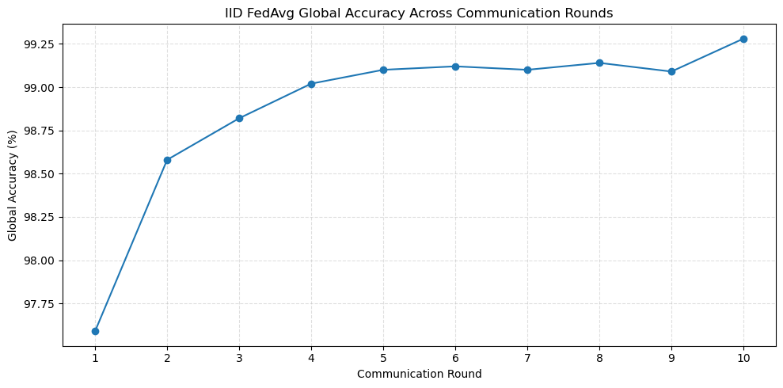

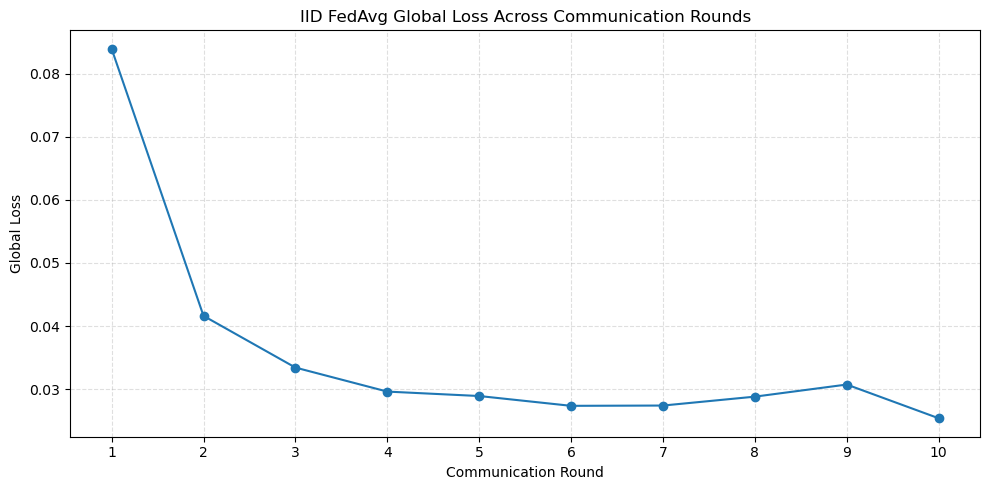

```
CONVERGENCE SUMMARY
----------------------------------------------------------------------------------------------------
Initial global accuracy : 97.59%
Final global accuracy   : 99.28%
Best global accuracy    : 99.28% at Round 10
Lowest global loss      : 0.0254 at Round 10
```

```python
# Display round-wise IID performance
iid_round_display = iid_round_history_epoch_2.copy()

iid_round_display["Global Accuracy (%)"] = (
    iid_round_display["Global Accuracy"] * 100
)

iid_round_display = iid_round_display[
    [
        "Round",
        "Local Epochs",
        "Global Loss",
        "Global Accuracy (%)"
    ]
]

print("=" * 100)
print("IID ROUND-WISE GLOBAL PERFORMANCE")
print("=" * 100)

display(
    iid_round_display.style.format({
        "Global Loss": "{:.4f}",
        "Global Accuracy (%)": "{:.2f}%"
    })
)

# Global accuracy curve
plt.figure(figsize=(10, 5))

plt.plot(
    iid_round_history_epoch_2["Round"],
    iid_round_history_epoch_2["Global Accuracy"] * 100,
    marker="o"
)

plt.title("IID FedAvg Global Accuracy Across Communication Rounds")
plt.xlabel("Communication Round")
plt.ylabel("Global Accuracy (%)")
plt.xticks(range(1, 11))
plt.grid(linestyle="--", alpha=0.4)
plt.tight_layout()
plt.show()

# Global loss curve
plt.figure(figsize=(10, 5))

plt.plot(
    iid_round_history_epoch_2["Round"],
    iid_round_history_epoch_2["Global Loss"],
    marker="o"
)

plt.title("IID FedAvg Global Loss Across Communication Rounds")
plt.xlabel("Communication Round")
plt.ylabel("Global Loss")
plt.xticks(range(1, 11))
plt.grid(linestyle="--", alpha=0.4)
plt.tight_layout()
plt.show()

# Convergence summary
best_accuracy_row = iid_round_history_epoch_2.loc[
    iid_round_history_epoch_2["Global Accuracy"].idxmax()
]

lowest_loss_row = iid_round_history_epoch_2.loc[
    iid_round_history_epoch_2["Global Loss"].idxmin()
]

print("\nCONVERGENCE SUMMARY")
print("-" * 100)

print(
    f"Initial global accuracy : "
    f"{iid_round_history_epoch_2.iloc[0]['Global Accuracy'] * 100:.2f}%"
)

print(
    f"Final global accuracy   : "
    f"{iid_round_history_epoch_2.iloc[-1]['Global Accuracy'] * 100:.2f}%"
)

print(
    f"Best global accuracy    : "
    f"{best_accuracy_row['Global Accuracy'] * 100:.2f}% "
    f"at Round {int(best_accuracy_row['Round'])}"
)

print(
    f"Lowest global loss      : "
    f"{lowest_loss_row['Global Loss']:.4f} "
    f"at Round {int(lowest_loss_row['Round'])}"
)
```

#### Observations

- Global accuracy increases from **97.59%** in Round 1 to **99.28%** in Round 10.
- The lowest global loss is also reached in Round 10 at **0.0254**, indicating stable convergence in the rerun.
- Most improvement occurs in the early rounds, with only small gains after approximately Round 5.

🔝 Back to Table of Contents

### 26. Experiment 1A: FedAvg with One Local Epoch

The first local-epoch experiment trains each IID client for one epoch during every communication round.

This configuration performs less local computation before aggregation and allows the global model to receive more frequent updates relative to the amount of client-side training. Its convergence will later be compared with local epoch settings of 2 and 5.

```python
iid_model_epoch_1, iid_round_history_epoch_1, iid_client_history_epoch_1 = (
    run_federated_training(
        client_datasets=iid_clients,
        communication_rounds=10,
        local_epochs=1,
        batch_size=32,
        experiment_name="IID FedAvg - Local Epoch 1",
        initial_weights=REFERENCE_INITIAL_WEIGHTS,
        verbose_local_training=0
    )
)
```

```
====================================================================================================
IID FEDAVG - LOCAL EPOCH 1
====================================================================================================
Communication rounds : 10
Local epochs         : 1
Batch size           : 32
Clients              : 5
Reference weights    : Applied

Communication Round 1/10
----------------------------------------------------------------------------------------------------
Client_1   | Samples: 12000 | Local Loss: 0.3810 | Local Accuracy: 88.11%
Client_2   | Samples: 12000 | Local Loss: 0.3866 | Local Accuracy: 88.26%
Client_3   | Samples: 12000 | Local Loss: 0.3771 | Local Accuracy: 88.57%
Client_4   | Samples: 12000 | Local Loss: 0.3826 | Local Accuracy: 88.13%
Client_5   | Samples: 12000 | Local Loss: 0.3741 | Local Accuracy: 88.63%

Global Loss     : 0.1267
Global Accuracy : 96.57%

Communication Round 2/10
----------------------------------------------------------------------------------------------------
Client_1   | Samples: 12000 | Local Loss: 0.1163 | Local Accuracy: 96.55%
Client_2   | Samples: 12000 | Local Loss: 0.1247 | Local Accuracy: 96.29%
Client_3   | Samples: 12000 | Local Loss: 0.1174 | Local Accuracy: 96.58%
Client_4   | Samples: 12000 | Local Loss: 0.1185 | Local Accuracy: 96.47%
Client_5   | Samples: 12000 | Local Loss: 0.1209 | Local Accuracy: 96.31%

Global Loss     : 0.0609
Global Accuracy : 98.04%

Communication Round 3/10
----------------------------------------------------------------------------------------------------
Client_1   | Samples: 12000 | Local Loss: 0.0790 | Local Accuracy: 97.62%
Client_2   | Samples: 12000 | Local Loss: 0.0859 | Local Accuracy: 97.32%
Client_3   | Samples: 12000 | Local Loss: 0.0805 | Local Accuracy: 97.62%
Client_4   | Samples: 12000 | Local Loss: 0.0814 | Local Accuracy: 97.59%
Client_5   | Samples: 12000 | Local Loss: 0.0844 | Local Accuracy: 97.27%

Global Loss     : 0.0455
```

[output cut: 72 more lines]

```
Client_3   | Samples: 12000 | Local Loss: 0.0260 | Local Accuracy: 99.21%
Client_4   | Samples: 12000 | Local Loss: 0.0270 | Local Accuracy: 99.22%
Client_5   | Samples: 12000 | Local Loss: 0.0255 | Local Accuracy: 99.23%

Global Loss     : 0.0286
Global Accuracy : 99.10%

====================================================================================================
FEDERATED TRAINING COMPLETED
====================================================================================================
Experiment name       : IID FedAvg - Local Epoch 1
Communication rounds  : 10
Local epochs          : 1
Batch size            : 32
Participating clients : 5
```

#### Observations

- With one local epoch, Round 1 client training accuracies range from **88.11% to 88.63%**, substantially below the two- and five-epoch configurations.
- The model nevertheless improves steadily across communication rounds, showing that frequent aggregation can compensate for lighter local computation.
- Final comparison with the other epoch settings is presented in Section 28.

🔝 Back to Table of Contents

### 27. Experiment 1B: FedAvg with Five Local Epochs

The second local-epoch experiment trains each IID client for five epochs during every communication round.

This configuration performs more local computation before aggregation. It may improve convergence per communication round, but it also increases client-side computation and can potentially lead to stronger local model drift.

```python
iid_model_epoch_5, iid_round_history_epoch_5, iid_client_history_epoch_5 = (
    run_federated_training(
        client_datasets=iid_clients,
        communication_rounds=10,
        local_epochs=5,
        batch_size=32,
        experiment_name="IID FedAvg - Local Epoch 5",
        initial_weights=REFERENCE_INITIAL_WEIGHTS,
        verbose_local_training=0
    )
)
```

```
====================================================================================================
IID FEDAVG - LOCAL EPOCH 5
====================================================================================================
Communication rounds : 10
Local epochs         : 5
Batch size           : 32
Clients              : 5
Reference weights    : Applied

Communication Round 1/10
----------------------------------------------------------------------------------------------------
Client_1   | Samples: 12000 | Local Loss: 0.0332 | Local Accuracy: 99.10%
Client_2   | Samples: 12000 | Local Loss: 0.0300 | Local Accuracy: 99.18%
Client_3   | Samples: 12000 | Local Loss: 0.0370 | Local Accuracy: 98.89%
Client_4   | Samples: 12000 | Local Loss: 0.0325 | Local Accuracy: 99.09%
Client_5   | Samples: 12000 | Local Loss: 0.0305 | Local Accuracy: 99.00%

Global Loss     : 0.0508
Global Accuracy : 98.36%

Communication Round 2/10
----------------------------------------------------------------------------------------------------
Client_1   | Samples: 12000 | Local Loss: 0.0109 | Local Accuracy: 99.73%
Client_2   | Samples: 12000 | Local Loss: 0.0116 | Local Accuracy: 99.68%
Client_3   | Samples: 12000 | Local Loss: 0.0148 | Local Accuracy: 99.42%
Client_4   | Samples: 12000 | Local Loss: 0.0146 | Local Accuracy: 99.50%
Client_5   | Samples: 12000 | Local Loss: 0.0173 | Local Accuracy: 99.39%

Global Loss     : 0.0349
Global Accuracy : 98.97%

Communication Round 3/10
----------------------------------------------------------------------------------------------------
Client_1   | Samples: 12000 | Local Loss: 0.0089 | Local Accuracy: 99.73%
Client_2   | Samples: 12000 | Local Loss: 0.0067 | Local Accuracy: 99.80%
Client_3   | Samples: 12000 | Local Loss: 0.0089 | Local Accuracy: 99.76%
Client_4   | Samples: 12000 | Local Loss: 0.0131 | Local Accuracy: 99.58%
Client_5   | Samples: 12000 | Local Loss: 0.0096 | Local Accuracy: 99.68%

Global Loss     : 0.0292
```

[output cut: 72 more lines]

```
Client_3   | Samples: 12000 | Local Loss: 0.0003 | Local Accuracy: 99.99%
Client_4   | Samples: 12000 | Local Loss: 0.0000 | Local Accuracy: 100.00%
Client_5   | Samples: 12000 | Local Loss: 0.0040 | Local Accuracy: 99.89%

Global Loss     : 0.0317
Global Accuracy : 99.26%

====================================================================================================
FEDERATED TRAINING COMPLETED
====================================================================================================
Experiment name       : IID FedAvg - Local Epoch 5
Communication rounds  : 10
Local epochs          : 5
Batch size            : 32
Participating clients : 5
```

#### Observations

- With five local epochs, Round 1 client training accuracy ranges from **98.89% to 99.18%**, showing much faster local fitting.
- The best global accuracy is **99.30%** at Round 9, while the final accuracy is **99.26%**.
- The small late-round loss fluctuations indicate diminishing returns despite substantially greater local computation.

🔝 Back to Table of Contents

### 28. Experiment 1: Comparison of Local Epoch Settings

The performance of FedAvg is compared for local epoch values of 1, 2, and 5 under the same IID client distribution.

All experiments use the same CNN architecture, initial weights, batch size, communication rounds, and test dataset. This controlled comparison isolates the impact of increasing the amount of local training performed before each aggregation step.

```
==============================================================================================================
LOCAL EPOCH COMPARISON SUMMARY
==============================================================================================================
```

|  | Local Epochs | Round 1 Accuracy (%) | Final Accuracy (%) | Best Accuracy (%) | Best Accuracy Round | Final Loss | Lowest Loss | Lowest Loss Round |
| --- | --- | --- | --- | --- | --- | --- | --- | --- |
| 0 | 1 | 96.57% | 99.10% | 99.17% | 9 | 0.0286 | 0.0274 | 9 |
| 1 | 2 | 97.59% | 99.28% | 99.28% | 10 | 0.0254 | 0.0254 | 10 |
| 2 | 5 | 98.36% | 99.26% | 99.30% | 9 | 0.0317 | 0.0279 | 5 |

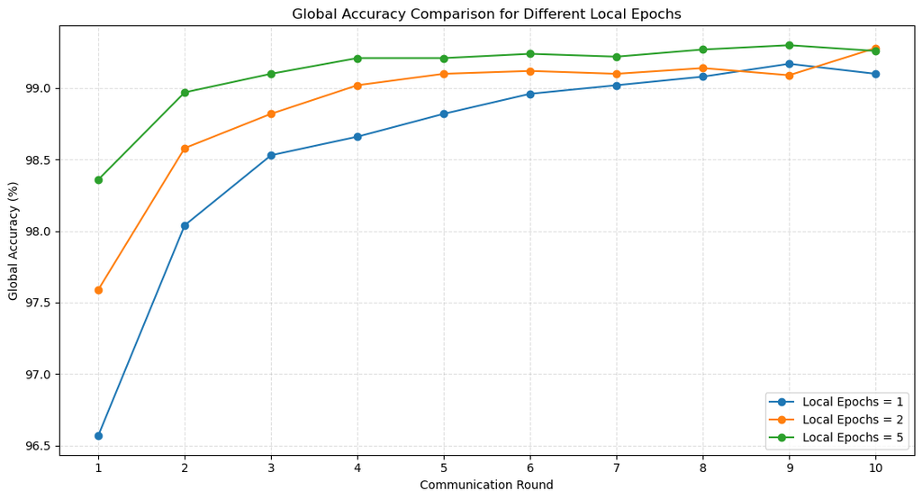

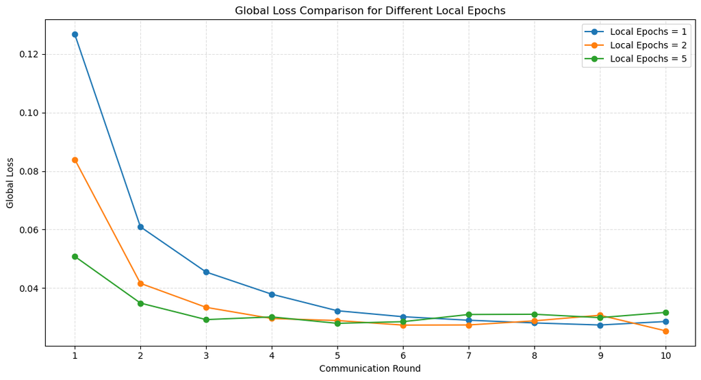

```python
# Combine round-wise histories for local epoch comparison
epoch_comparison_history = pd.concat(
    [
        iid_round_history_epoch_1,
        iid_round_history_epoch_2,
        iid_round_history_epoch_5
    ],
    ignore_index=True
)

# Build final summary table
epoch_summary_records = []

for epoch_value, history in [
    (1, iid_round_history_epoch_1),
    (2, iid_round_history_epoch_2),
    (5, iid_round_history_epoch_5)
]:
    best_accuracy_row = history.loc[
        history["Global Accuracy"].idxmax()
    ]

    lowest_loss_row = history.loc[
        history["Global Loss"].idxmin()
    ]

    epoch_summary_records.append({
        "Local Epochs": epoch_value,
        "Round 1 Accuracy (%)": (
            history.iloc[0]["Global Accuracy"] * 100
        ),
        "Final Accuracy (%)": (
            history.iloc[-1]["Global Accuracy"] * 100
        ),
        "Best Accuracy (%)": (
            best_accuracy_row["Global Accuracy"] * 100
        ),
        "Best Accuracy Round": int(
            best_accuracy_row["Round"]
        ),
        "Final Loss": history.iloc[-1]["Global Loss"],
        "Lowest Loss": lowest_loss_row["Global Loss"],
        "Lowest Loss Round": int(
            lowest_loss_row["Round"]
        )
    })

epoch_comparison_summary = pd.DataFrame(
    epoch_summary_records
)

print("=" * 110)
print("LOCAL EPOCH COMPARISON SUMMARY")
print("=" * 110)

display(
    epoch_comparison_summary.style.format({
        "Round 1 Accuracy (%)": "{:.2f}%",
        "Final Accuracy (%)": "{:.2f}%",
        "Best Accuracy (%)": "{:.2f}%",
        "Final Loss": "{:.4f}",
        "Lowest Loss": "{:.4f}"
    })
)

# Accuracy comparison
plt.figure(figsize=(11, 6))

for epoch_value, history in [
    (1, iid_round_history_epoch_1),
    (2, iid_round_history_epoch_2),
    (5, iid_round_history_epoch_5)
]:
    plt.plot(
        history["Round"],
        history["Global Accuracy"] * 100,
        marker="o",
        label=f"Local Epochs = {epoch_value}"
    )

plt.title("Global Accuracy Comparison for Different Local Epochs")
plt.xlabel("Communication Round")
plt.ylabel("Global Accuracy (%)")
plt.xticks(range(1, 11))
plt.legend()
plt.grid(linestyle="--", alpha=0.4)
plt.tight_layout()
plt.show()

# Loss comparison
plt.figure(figsize=(11, 6))

for epoch_value, history in [
    (1, iid_round_history_epoch_1),
    (2, iid_round_history_epoch_2),
    (5, iid_round_history_epoch_5)
]:
    plt.plot(
        history["Round"],
        history["Global Loss"],
        marker="o",
        label=f"Local Epochs = {epoch_value}"
    )

plt.title("Global Loss Comparison for Different Local Epochs")
plt.xlabel("Communication Round")
plt.ylabel("Global Loss")
plt.xticks(range(1, 11))
plt.legend()
plt.grid(linestyle="--", alpha=0.4)
plt.tight_layout()
plt.show()
```

#### Observations

- Final global accuracy is **99.10%**, **99.28%**, and **99.26%** for 1, 2, and 5 local epochs respectively.
- Five local epochs achieve the highest observed accuracy (**99.30% at Round 9**), but two local epochs produce the best final loss (**0.0254**) and the best final accuracy (**99.28%**).
- The results show diminishing returns: increasing local computation from two to five epochs does not improve the final model in this rerun.

🔝 Back to Table of Contents

### 29. Experiment 2: FedAvg Training on Non-IID Clients

The federated-learning workflow is now executed using the Non-IID client datasets.

Each client contains a strongly skewed label distribution, while the model architecture, initial weights, batch size, number of communication rounds, and local epochs remain identical to the IID baseline. This controlled experiment isolates the impact of client data heterogeneity on FedAvg convergence and global-model performance.

```python
non_iid_model_epoch_2, non_iid_round_history_epoch_2, non_iid_client_history_epoch_2 = (
    run_federated_training(
        client_datasets=non_iid_clients,
        communication_rounds=10,
        local_epochs=2,
        batch_size=32,
        experiment_name="Non-IID FedAvg - Local Epoch 2",
        initial_weights=REFERENCE_INITIAL_WEIGHTS,
        verbose_local_training=0
    )
)
```

```
====================================================================================================
NON-IID FEDAVG - LOCAL EPOCH 2
====================================================================================================
Communication rounds : 10
Local epochs         : 2
Batch size           : 32
Clients              : 5
Reference weights    : Applied

Communication Round 1/10
----------------------------------------------------------------------------------------------------
Client_1   | Samples: 12000 | Local Loss: 0.0208 | Local Accuracy: 99.33%
Client_2   | Samples: 12000 | Local Loss: 0.0080 | Local Accuracy: 99.76%
Client_3   | Samples: 12000 | Local Loss: 0.0277 | Local Accuracy: 99.09%
Client_4   | Samples: 12000 | Local Loss: 0.0390 | Local Accuracy: 98.81%
Client_5   | Samples: 12000 | Local Loss: 0.0171 | Local Accuracy: 99.39%

Global Loss     : 1.7256
Global Accuracy : 41.06%

Communication Round 2/10
----------------------------------------------------------------------------------------------------
Client_1   | Samples: 12000 | Local Loss: 0.0164 | Local Accuracy: 99.46%
Client_2   | Samples: 12000 | Local Loss: 0.0046 | Local Accuracy: 99.85%
Client_3   | Samples: 12000 | Local Loss: 0.0217 | Local Accuracy: 99.36%
Client_4   | Samples: 12000 | Local Loss: 0.0286 | Local Accuracy: 99.02%
Client_5   | Samples: 12000 | Local Loss: 0.0113 | Local Accuracy: 99.58%

Global Loss     : 1.2460
Global Accuracy : 56.56%

Communication Round 3/10
----------------------------------------------------------------------------------------------------
Client_1   | Samples: 12000 | Local Loss: 0.0112 | Local Accuracy: 99.63%
Client_2   | Samples: 12000 | Local Loss: 0.0009 | Local Accuracy: 99.99%
Client_3   | Samples: 12000 | Local Loss: 0.0160 | Local Accuracy: 99.45%
Client_4   | Samples: 12000 | Local Loss: 0.0229 | Local Accuracy: 99.32%
Client_5   | Samples: 12000 | Local Loss: 0.0074 | Local Accuracy: 99.74%

Global Loss     : 1.0336
```

[output cut: 72 more lines]

```
Client_3   | Samples: 12000 | Local Loss: 0.0047 | Local Accuracy: 99.83%
Client_4   | Samples: 12000 | Local Loss: 0.0088 | Local Accuracy: 99.67%
Client_5   | Samples: 12000 | Local Loss: 0.0024 | Local Accuracy: 99.92%

Global Loss     : 0.6967
Global Accuracy : 78.76%

====================================================================================================
FEDERATED TRAINING COMPLETED
====================================================================================================
Experiment name       : Non-IID FedAvg - Local Epoch 2
Communication rounds  : 10
Local epochs          : 2
Batch size            : 32
Participating clients : 5
```

#### Observations

- Round 1 client training accuracies remain very high (**98.81%–99.76%**) because each client trains on a narrow subset of labels.
- In contrast, the global model begins at only **41.06%** accuracy on the full ten-class test set.
- This gap shows that high local training accuracy is not sufficient evidence of good global generalization under strongly Non-IID data.

🔝 Back to Table of Contents

### 30. Experiment 2: IID versus Non-IID Performance Comparison

The global performance of FedAvg is compared under IID and Non-IID client distributions.

Both experiments use the same CNN architecture, reference initialization, batch size, two local epochs, five clients, and ten communication rounds. Therefore, the comparison isolates the effect of client data heterogeneity on convergence, accuracy, and loss.

```
==============================================================================================================
IID VERSUS NON-IID PERFORMANCE SUMMARY
==============================================================================================================
```

|  | Data Distribution | Round 1 Accuracy (%) | Final Accuracy (%) | Best Accuracy (%) | Final Loss | Lowest Loss |
| --- | --- | --- | --- | --- | --- | --- |
| 0 | IID | 97.59% | 99.28% | 99.28% | 0.0254 | 0.0254 |
| 1 | Non-IID | 41.06% | 78.76% | 78.76% | 0.6967 | 0.6967 |

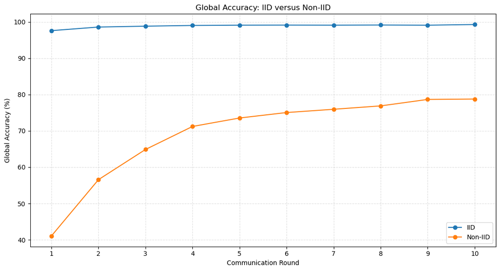

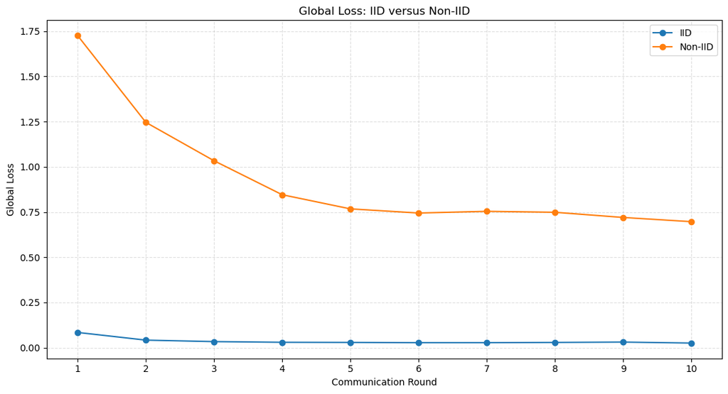

```
FINAL PERFORMANCE GAP
--------------------------------------------------------------------------------------------------------------
Final accuracy gap : 20.52 percentage points
Final loss gap     : 0.6713
```

```python
# Build IID versus Non-IID comparison summary
iid_non_iid_summary = pd.DataFrame([
    {
        "Data Distribution": "IID",
        "Round 1 Accuracy (%)":
            iid_round_history_epoch_2.iloc[0]["Global Accuracy"] * 100,
        "Final Accuracy (%)":
            iid_round_history_epoch_2.iloc[-1]["Global Accuracy"] * 100,
        "Best Accuracy (%)":
            iid_round_history_epoch_2["Global Accuracy"].max() * 100,
        "Final Loss":
            iid_round_history_epoch_2.iloc[-1]["Global Loss"],
        "Lowest Loss":
            iid_round_history_epoch_2["Global Loss"].min()
    },
    {
        "Data Distribution": "Non-IID",
        "Round 1 Accuracy (%)":
            non_iid_round_history_epoch_2.iloc[0]["Global Accuracy"] * 100,
        "Final Accuracy (%)":
            non_iid_round_history_epoch_2.iloc[-1]["Global Accuracy"] * 100,
        "Best Accuracy (%)":
            non_iid_round_history_epoch_2["Global Accuracy"].max() * 100,
        "Final Loss":
            non_iid_round_history_epoch_2.iloc[-1]["Global Loss"],
        "Lowest Loss":
            non_iid_round_history_epoch_2["Global Loss"].min()
    }
])

print("=" * 110)
print("IID VERSUS NON-IID PERFORMANCE SUMMARY")
print("=" * 110)

display(
    iid_non_iid_summary.style.format({
        "Round 1 Accuracy (%)": "{:.2f}%",
        "Final Accuracy (%)": "{:.2f}%",
        "Best Accuracy (%)": "{:.2f}%",
        "Final Loss": "{:.4f}",
        "Lowest Loss": "{:.4f}"
    })
)

# Accuracy comparison
plt.figure(figsize=(11, 6))

plt.plot(
    iid_round_history_epoch_2["Round"],
    iid_round_history_epoch_2["Global Accuracy"] * 100,
    marker="o",
    label="IID"
)

plt.plot(
    non_iid_round_history_epoch_2["Round"],
    non_iid_round_history_epoch_2["Global Accuracy"] * 100,
    marker="o",
    label="Non-IID"
)

plt.title("Global Accuracy: IID versus Non-IID")
plt.xlabel("Communication Round")
plt.ylabel("Global Accuracy (%)")
plt.xticks(range(1, 11))
plt.legend()
plt.grid(linestyle="--", alpha=0.4)
plt.tight_layout()
plt.show()

# Loss comparison
plt.figure(figsize=(11, 6))

plt.plot(
    iid_round_history_epoch_2["Round"],
    iid_round_history_epoch_2["Global Loss"],
    marker="o",
    label="IID"
)

plt.plot(
    non_iid_round_history_epoch_2["Round"],
    non_iid_round_history_epoch_2["Global Loss"],
    marker="o",
    label="Non-IID"
)

plt.title("Global Loss: IID versus Non-IID")
plt.xlabel("Communication Round")
plt.ylabel("Global Loss")
plt.xticks(range(1, 11))
plt.legend()
plt.grid(linestyle="--", alpha=0.4)
plt.tight_layout()
plt.show()

# Quantify final performance gap
final_accuracy_gap = (
    iid_round_history_epoch_2.iloc[-1]["Global Accuracy"]
    - non_iid_round_history_epoch_2.iloc[-1]["Global Accuracy"]
) * 100

final_loss_gap = (
    non_iid_round_history_epoch_2.iloc[-1]["Global Loss"]
    - iid_round_history_epoch_2.iloc[-1]["Global Loss"]
)

print("\nFINAL PERFORMANCE GAP")
print("-" * 110)
print(f"Final accuracy gap : {final_accuracy_gap:.2f} percentage points")
print(f"Final loss gap     : {final_loss_gap:.4f}")
```

#### Observations

- With identical initialization and hyperparameters, IID training finishes at **99.28%** accuracy, while Non-IID training finishes at **78.76%**.
- The final accuracy gap is **20.52 percentage points**, and the final loss gap is **0.6713**.
- The difference is attributable to label-distribution heterogeneity, which causes locally specialized updates to be less compatible during aggregation.

#### 30.1 Proxy Analysis of Client Drift: Dispersion of Local Training Accuracy

Client drift is fundamentally a divergence in local model updates under heterogeneous data. Directly measuring weight-vector divergence would require storing every client's full update tensor for every round. As a lightweight diagnostic, this notebook compares the round-wise standard deviation of **local training accuracy** across the five clients.

A higher dispersion indicates that clients are progressing differently on their local objectives. This is used only as a **proxy** for heterogeneous client behavior, not as a direct measurement of parameter-space drift.

```
==============================================================================================================
CLIENT DRIFT: DISPERSION OF LOCAL ACCURACY ACROSS CLIENTS PER ROUND
==============================================================================================================
```

| Round | IID Client Accuracy Std Dev (%) | Non-IID Client Accuracy Std Dev (%) |
| --- | --- | --- |
| 1 | 0.257 | 0.354 |
| 2 | 0.025 | 0.303 |
| 3 | 0.061 | 0.262 |
| 4 | 0.083 | 0.231 |
| 5 | 0.095 | 0.172 |
| 6 | 0.049 | 0.145 |
| 7 | 0.068 | 0.117 |
| 8 | 0.065 | 0.118 |
| 9 | 0.032 | 0.106 |
| 10 | 0.075 | 0.122 |

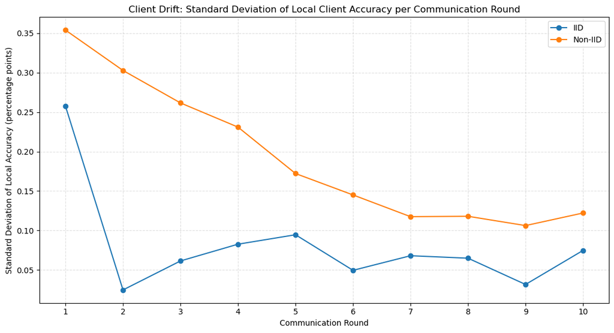

```
SUMMARY
--------------------------------------------------------------------------------------------------------------
Mean IID client-accuracy std dev     : 0.081 pp
Mean Non-IID client-accuracy std dev : 0.193 pp
Non-IID clients disagree with each other, on average, 2.39x more than IID clients.
```

```python
# Quantify client drift as the round-wise standard deviation of local
# client accuracy. A HIGHER standard deviation means the five clients'
# locally trained models disagree more with each other before aggregation.

iid_dispersion = (
    iid_client_history_epoch_2
    .groupby("Round")["Local Accuracy"]
    .std()
    .rename("IID Client Accuracy Std Dev (%)") * 100
)

non_iid_dispersion = (
    non_iid_client_history_epoch_2
    .groupby("Round")["Local Accuracy"]
    .std()
    .rename("Non-IID Client Accuracy Std Dev (%)") * 100
)

dispersion_comparison = pd.concat(
    [iid_dispersion, non_iid_dispersion], axis=1
)

print("=" * 110)
print("CLIENT DRIFT: DISPERSION OF LOCAL ACCURACY ACROSS CLIENTS PER ROUND")
print("=" * 110)

display(
    dispersion_comparison.style.format("{:.3f}")
)

plt.figure(figsize=(11, 6))

plt.plot(
    dispersion_comparison.index,
    dispersion_comparison["IID Client Accuracy Std Dev (%)"],
    marker="o",
    label="IID"
)

plt.plot(
    dispersion_comparison.index,
    dispersion_comparison["Non-IID Client Accuracy Std Dev (%)"],
    marker="o",
    label="Non-IID"
)

plt.title(
    "Client Drift: Standard Deviation of Local Client Accuracy "
    "per Communication Round"
)
plt.xlabel("Communication Round")
plt.ylabel("Standard Deviation of Local Accuracy (percentage points)")
plt.xticks(range(1, 11))
plt.legend()
plt.grid(linestyle="--", alpha=0.4)
plt.tight_layout()
plt.show()

mean_iid_dispersion = dispersion_comparison["IID Client Accuracy Std Dev (%)"].mean()
mean_non_iid_dispersion = dispersion_comparison["Non-IID Client Accuracy Std Dev (%)"].mean()

print("\nSUMMARY")
print("-" * 110)
print(f"Mean IID client-accuracy std dev     : {mean_iid_dispersion:.3f} pp")
print(f"Mean Non-IID client-accuracy std dev : {mean_non_iid_dispersion:.3f} pp")
print(
    f"Non-IID clients disagree with each other, on average, "
    f"{mean_non_iid_dispersion / mean_iid_dispersion:.2f}x more than IID clients."
    if mean_iid_dispersion > 0 else ""
)
```

#### Observations

- Mean local-accuracy dispersion is **0.081 percentage points** for IID clients and **0.193 percentage points** for Non-IID clients.
- The Non-IID dispersion is **2.39×** higher, indicating less uniform local progress across clients.
- This metric is a behavioral proxy; the stronger evidence of harmful heterogeneity remains the large global accuracy and loss gap.

🔝 Back to Table of Contents

### 31. Final Global Model Class-Wise Evaluation

Confusion matrices are generated for the final IID and Non-IID global models to examine class-wise prediction performance.

This analysis identifies which digit classes are classified correctly and which classes are most affected by the heterogeneous Non-IID client distribution.

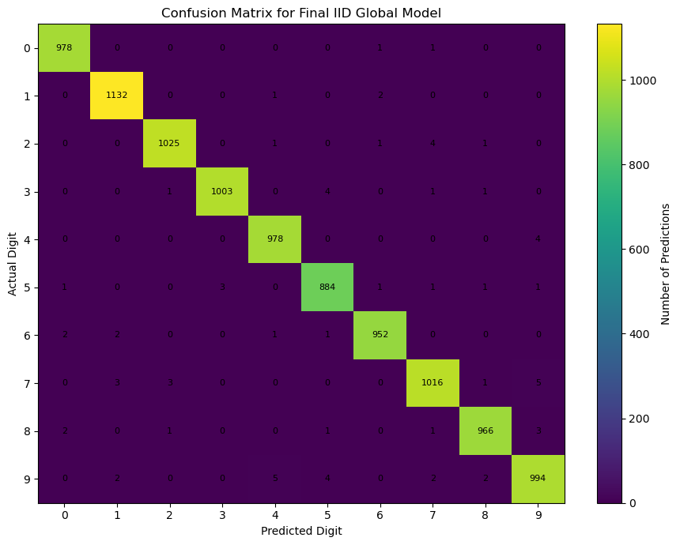

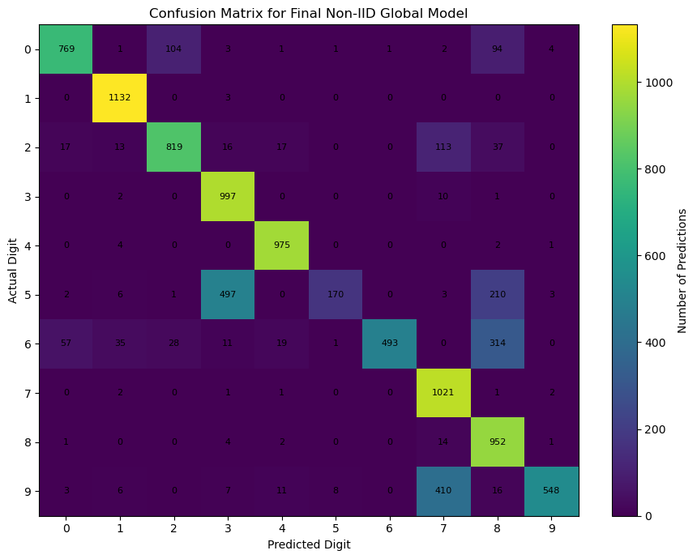

```
========================================================================================================================
CLASS-WISE IID AND NON-IID PERFORMANCE
========================================================================================================================
```

|  | Digit | IID Precision | IID Recall | IID F1-Score | Non-IID Precision | Non-IID Recall | Non-IID F1-Score |
| --- | --- | --- | --- | --- | --- | --- | --- |
| 0 | 0 | 0.995 | 0.998 | 0.996 | 0.906 | 0.785 | 0.841 |
| 1 | 1 | 0.994 | 0.997 | 0.996 | 0.943 | 0.997 | 0.969 |
| 2 | 2 | 0.995 | 0.993 | 0.994 | 0.860 | 0.794 | 0.826 |
| 3 | 3 | 0.997 | 0.993 | 0.995 | 0.648 | 0.987 | 0.782 |
| 4 | 4 | 0.992 | 0.996 | 0.994 | 0.950 | 0.993 | 0.971 |
| 5 | 5 | 0.989 | 0.991 | 0.990 | 0.944 | 0.191 | 0.317 |
| 6 | 6 | 0.995 | 0.994 | 0.994 | 0.998 | 0.515 | 0.679 |
| 7 | 7 | 0.990 | 0.988 | 0.989 | 0.649 | 0.993 | 0.785 |
| 8 | 8 | 0.994 | 0.992 | 0.993 | 0.585 | 0.977 | 0.732 |
| 9 | 9 | 0.987 | 0.985 | 0.986 | 0.980 | 0.543 | 0.699 |

```python
from sklearn.metrics import confusion_matrix, classification_report

# Generate predictions from the final global models
iid_predictions = np.argmax(
    iid_model_epoch_2.predict(x_test_processed, verbose=0),
    axis=1
)

non_iid_predictions = np.argmax(
    non_iid_model_epoch_2.predict(x_test_processed, verbose=0),
    axis=1
)

# Compute confusion matrices
iid_confusion_matrix = confusion_matrix(
    y_test,
    iid_predictions
)

non_iid_confusion_matrix = confusion_matrix(
    y_test,
    non_iid_predictions
)

# Plot IID confusion matrix
plt.figure(figsize=(9, 7))

plt.imshow(iid_confusion_matrix, aspect="auto")
plt.title("Confusion Matrix for Final IID Global Model")
plt.xlabel("Predicted Digit")
plt.ylabel("Actual Digit")
plt.xticks(range(10))
plt.yticks(range(10))

for row in range(10):
    for column in range(10):
        plt.text(
            column,
            row,
            iid_confusion_matrix[row, column],
            ha="center",
            va="center",
            fontsize=8
        )

plt.colorbar(label="Number of Predictions")
plt.tight_layout()
plt.show()

# Plot Non-IID confusion matrix
plt.figure(figsize=(9, 7))

plt.imshow(non_iid_confusion_matrix, aspect="auto")
plt.title("Confusion Matrix for Final Non-IID Global Model")
plt.xlabel("Predicted Digit")
plt.ylabel("Actual Digit")
plt.xticks(range(10))
plt.yticks(range(10))

for row in range(10):
    for column in range(10):
        plt.text(
            column,
            row,
            non_iid_confusion_matrix[row, column],
            ha="center",
            va="center",
            fontsize=8
        )

plt.colorbar(label="Number of Predictions")
plt.tight_layout()
plt.show()

# Generate class-wise performance summaries
iid_classification_report = classification_report(
    y_test,
    iid_predictions,
    output_dict=True,
    zero_division=0
)

non_iid_classification_report = classification_report(
    y_test,
    non_iid_predictions,
    output_dict=True,
    zero_division=0
)

classwise_comparison = []

for digit in range(10):
    digit_key = str(digit)

    classwise_comparison.append({
        "Digit": digit,
        "IID Precision": iid_classification_report[digit_key]["precision"],
        "IID Recall": iid_classification_report[digit_key]["recall"],
        "IID F1-Score": iid_classification_report[digit_key]["f1-score"],
        "Non-IID Precision": non_iid_classification_report[digit_key]["precision"],
        "Non-IID Recall": non_iid_classification_report[digit_key]["recall"],
        "Non-IID F1-Score": non_iid_classification_report[digit_key]["f1-score"]
    })

classwise_comparison = pd.DataFrame(classwise_comparison)

print("=" * 120)
print("CLASS-WISE IID AND NON-IID PERFORMANCE")
print("=" * 120)

display(
    classwise_comparison.style.format({
        "IID Precision": "{:.3f}",
        "IID Recall": "{:.3f}",
        "IID F1-Score": "{:.3f}",
        "Non-IID Precision": "{:.3f}",
        "Non-IID Recall": "{:.3f}",
        "Non-IID F1-Score": "{:.3f}"
    })
)
```

#### 31.1 Visual Class-Wise F1-Score Comparison

The table in Section 31 lists precision, recall and F1-score for every digit under both global models. The grouped bar chart below visualises the F1-score column directly, making the classes most damaged by Non-IID training immediately visible without reading down the table row by row.

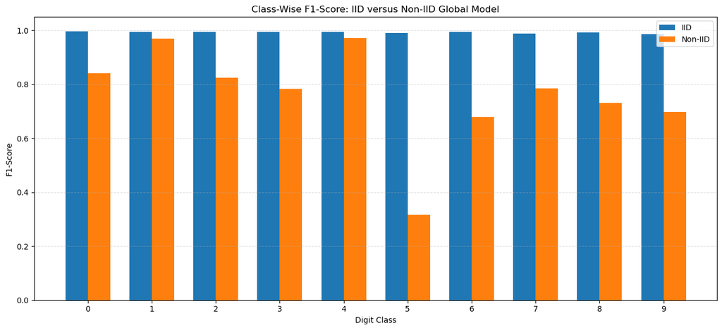

```
MOST AFFECTED CLASS
----------------------------------------------------------------------------------------------------
Digit with the largest IID-to-Non-IID F1-score drop : 5
F1-score drop for that digit                        : 0.673
```

```python
# Visualise the class-wise F1-score table from Section 31 as a grouped
# bar chart, and identify the single most-affected digit class.

bar_width = 0.35
x_positions = np.arange(10)

plt.figure(figsize=(13, 6))

plt.bar(
    x_positions - bar_width / 2,
    classwise_comparison["IID F1-Score"],
    width=bar_width,
    label="IID"
)

plt.bar(
    x_positions + bar_width / 2,
    classwise_comparison["Non-IID F1-Score"],
    width=bar_width,
    label="Non-IID"
)

plt.title("Class-Wise F1-Score: IID versus Non-IID Global Model")
plt.xlabel("Digit Class")
plt.ylabel("F1-Score")
plt.xticks(x_positions)
plt.ylim(0, 1.05)
plt.legend()
plt.grid(axis="y", linestyle="--", alpha=0.4)
plt.tight_layout()
plt.show()

f1_drop = (
    classwise_comparison["IID F1-Score"]
    - classwise_comparison["Non-IID F1-Score"]
)
weakest_digit = int(classwise_comparison.loc[f1_drop.idxmax(), "Digit"])

print("\nMOST AFFECTED CLASS")
print("-" * 100)
print(f"Digit with the largest IID-to-Non-IID F1-score drop : {weakest_digit}")
print(f"F1-score drop for that digit                        : {f1_drop.max():.3f}")
```

#### Observations

- The IID model maintains F1-scores of approximately **0.986–0.996** across all digits.
- Under Non-IID training, digit **5** is most affected: its F1-score falls from **0.990** to **0.317**, a drop of **0.673**.
- Digits 1 and 4 remain comparatively strong, while the uneven class-wise results confirm bias introduced by skewed client label distributions.

🔝 Back to Table of Contents

### 32. Consolidated Experimental Findings

The IID configuration converged rapidly. With two local epochs, global accuracy increased from **97.59%** in Round 1 to **99.28%** after ten rounds, with the lowest loss of **0.0254** also occurring in Round 10.

The local-epoch comparison produced final accuracies of **99.10%**, **99.28%**, and **99.26%** for 1, 2, and 5 local epochs respectively. Five epochs achieved the highest intermediate accuracy (**99.30% at Round 9**), but two epochs delivered the strongest final result in this rerun with lower computational cost than five epochs.

The Non-IID model improved from **41.06%** to **78.76%**, but remained **20.52 percentage points** below the IID model. Local client training accuracies remained near 100%, demonstrating that client-level fit can coexist with weak global generalization when label distributions are highly skewed.

Class-wise results confirm uneven Non-IID performance. Digit **5** is the most affected class, with its F1-score falling from **0.990** under IID training to **0.317** under Non-IID training.

🔝 Back to Table of Contents

### 33. Critical Analysis

#### Why does FedAvg perform differently on IID and Non-IID data?

IID clients contain similar class proportions, so their local objectives and updates are broadly aligned. This produced rapid and stable convergence to **99.28%** global accuracy.

Non-IID clients are dominated by different labels, causing local specialization and conflicting updates. Although local training accuracy remained near 100%, the global model reached only **78.76%**, demonstrating weaker generalization.

#### What is the impact of increasing local epochs?

More local epochs improve the amount of learning completed before each communication event. In this experiment, five epochs improved early-round accuracy but finished at **99.26%**, slightly below the two-epoch result of **99.28%**, while requiring 2.5 times as much local training per round.

Therefore, additional local epochs can reduce communication needs but may provide diminishing returns and, under Non-IID data, can intensify client specialization.

#### Improvement over Standard FedAvg

**FedProx** adds a proximal term to each client's local objective, penalizing large deviation from the current global weights. This can reduce local drift and improve stability under heterogeneous client distributions. This assignment identifies FedProx as the appropriate extension for improving stability under heterogeneous client distributions; its implementation remains outside the defined assignment scope.

🔝 Back to Table of Contents

### 34. Limitations and Practical Considerations

The implementation successfully demonstrates the FedAvg workflow, but it represents a controlled simulation rather than a production federated-learning deployment.

- All five clients are simulated sequentially within one Kubeflow environment rather than running on physically separate systems.
- All clients participate in every communication round; client dropout and partial participation are not considered.
- Communication latency, network failures, bandwidth consumption, and model-transfer cost are not measured.
- All clients have equal dataset sizes and identical computing capacity.
- The Non-IID distribution is intentionally strong and is created using label-based shards.
- Only the standard FedAvg algorithm is implemented; methods such as FedProx are discussed but not experimentally evaluated.
- Privacy mechanisms such as secure aggregation, encryption, and differential privacy are outside the scope of this assignment.
- The experiment uses MNIST and a lightweight CNN, so the results may not directly represent larger real-world medical-image datasets.

🔝 Back to Table of Contents

### 35. Conclusion

This assignment implemented Federated Averaging manually for MNIST image classification using five simulated clients. Both IID and label-shard Non-IID partitions were evaluated without using TensorFlow Federated, Flower, FedML, PySyft, or any other federated-learning framework.

Under IID data, the two-local-epoch configuration reached **99.28%** global accuracy and **0.0254** loss after ten communication rounds. Increasing local epochs to five improved early-round learning but did not improve the final result, illustrating diminishing returns from additional client-side computation.

Under Non-IID data, final global accuracy was **78.76%**, producing a **20.52 percentage-point** gap relative to the equivalent IID run. The class-wise analysis showed substantial bias, particularly for digit 5.

The results demonstrate that standard FedAvg performs strongly when client distributions are similar but is sensitive to severe statistical heterogeneity. FedProx or related drift-control methods are appropriate directions for future work.

🔝 Back to Table of Contents

### 36. Final Experiment Summary

The key results from all federated-learning experiments are consolidated into a single table. This provides a direct comparison of data distribution, local epochs, convergence behaviour, final accuracy, and final loss.

```python
final_experiment_summary = pd.DataFrame([
    {
        "Experiment": "IID - Local Epoch 1",
        "Distribution": "IID",
        "Local Epochs": 1,
        "Communication Rounds": 10,
        "Initial Accuracy (%)":
            iid_round_history_epoch_1.iloc[0]["Global Accuracy"] * 100,
        "Final Accuracy (%)":
            iid_round_history_epoch_1.iloc[-1]["Global Accuracy"] * 100,
        "Best Accuracy (%)":
            iid_round_history_epoch_1["Global Accuracy"].max() * 100,
        "Final Loss":
            iid_round_history_epoch_1.iloc[-1]["Global Loss"]
    },
    {
        "Experiment": "IID - Local Epoch 2",
        "Distribution": "IID",
        "Local Epochs": 2,
        "Communication Rounds": 10,
        "Initial Accuracy (%)":
            iid_round_history_epoch_2.iloc[0]["Global Accuracy"] * 100,
        "Final Accuracy (%)":
            iid_round_history_epoch_2.iloc[-1]["Global Accuracy"] * 100,
        "Best Accuracy (%)":
            iid_round_history_epoch_2["Global Accuracy"].max() * 100,
        "Final Loss":
            iid_round_history_epoch_2.iloc[-1]["Global Loss"]
    },
    {
        "Experiment": "IID - Local Epoch 5",
        "Distribution": "IID",
        "Local Epochs": 5,
        "Communication Rounds": 10,
        "Initial Accuracy (%)":
            iid_round_history_epoch_5.iloc[0]["Global Accuracy"] * 100,
        "Final Accuracy (%)":
            iid_round_history_epoch_5.iloc[-1]["Global Accuracy"] * 100,
        "Best Accuracy (%)":
            iid_round_history_epoch_5["Global Accuracy"].max() * 100,
        "Final Loss":
            iid_round_history_epoch_5.iloc[-1]["Global Loss"]
    },
    {
        "Experiment": "Non-IID - Local Epoch 2",
        "Distribution": "Non-IID",
        "Local Epochs": 2,
        "Communication Rounds": 10,
        "Initial Accuracy (%)":
            non_iid_round_history_epoch_2.iloc[0]["Global Accuracy"] * 100,
        "Final Accuracy (%)":
            non_iid_round_history_epoch_2.iloc[-1]["Global Accuracy"] * 100,
        "Best Accuracy (%)":
            non_iid_round_history_epoch_2["Global Accuracy"].max() * 100,
        "Final Loss":
            non_iid_round_history_epoch_2.iloc[-1]["Global Loss"]
    }
])

print("=" * 120)
print("FINAL FEDERATED LEARNING EXPERIMENT SUMMARY")
print("=" * 120)

display(
    final_experiment_summary.style.format({
        "Initial Accuracy (%)": "{:.2f}%",
        "Final Accuracy (%)": "{:.2f}%",
        "Best Accuracy (%)": "{:.2f}%",
        "Final Loss": "{:.4f}"
    })
)
```

```
========================================================================================================================
FINAL FEDERATED LEARNING EXPERIMENT SUMMARY
========================================================================================================================
```

|  | Experiment | Distribution | Local Epochs | Communication Rounds | Initial Accuracy (%) | Final Accuracy (%) | Best Accuracy (%) | Final Loss |
| --- | --- | --- | --- | --- | --- | --- | --- | --- |
| 0 | IID - Local Epoch 1 | IID | 1 | 10 | 96.57% | 99.10% | 99.17% | 0.0286 |
| 1 | IID - Local Epoch 2 | IID | 2 | 10 | 97.59% | 99.28% | 99.28% | 0.0254 |
| 2 | IID - Local Epoch 5 | IID | 5 | 10 | 98.36% | 99.26% | 99.30% | 0.0317 |
| 3 | Non-IID - Local Epoch 2 | Non-IID | 2 | 10 | 41.06% | 78.76% | 78.76% | 0.6967 |

🔝 Back to Table of Contents

### 37. References

1. LeCun, Y., Cortes, C., and Burges, C. J. C. *The MNIST Database of Handwritten Digits*.
2. McMahan, H. B., Moore, E., Ramage, D., Hampson, S., and Agüera y Arcas, B. “Communication-Efficient Learning of Deep Networks from Decentralized Data.” *Proceedings of the 20th International Conference on Artificial Intelligence and Statistics*, 2017.
3. TensorFlow. *TensorFlow and Keras Documentation*.
4. NumPy Developers. *NumPy Documentation*.
5. Pandas Development Team. *Pandas Documentation*.
6. Matplotlib Development Team. *Matplotlib Documentation*.
7. Li, T., Sahu, A. K., Talwalkar, A., and Smith, V. “Federated Optimization in Heterogeneous Networks.” *Proceedings of Machine Learning and Systems*, 2020.

🔝 Back to Table of Contents

### 38. Final Notebook Validation

The final validation checks confirm that all mandatory assignment components have been created successfully, including client partitions, manual FedAvg implementation, communication-round histories, experimental comparisons, and final evaluation outputs.

```python
required_objects = {
    "IID client datasets": "iid_clients",
    "Non-IID client datasets": "non_iid_clients",
    "CNN model function": "create_cnn_model",
    "Local client training function": "train_local_client",
    "Manual FedAvg function": "federated_average",
    "Global evaluation function": "evaluate_global_model",
    "Federated training function": "run_federated_training",
    "IID epoch-1 history": "iid_round_history_epoch_1",
    "IID epoch-2 history": "iid_round_history_epoch_2",
    "IID epoch-5 history": "iid_round_history_epoch_5",
    "Non-IID epoch-2 history": "non_iid_round_history_epoch_2",
    "Final experiment summary": "final_experiment_summary"
}

validation_results = []

for component, object_name in required_objects.items():
    exists = object_name in globals()

    validation_results.append({
        "Required Component": component,
        "Python Object": object_name,
        "Status": "Pass" if exists else "Fail"
    })

validation_results = pd.DataFrame(validation_results)

print("=" * 110)
print("FINAL NOTEBOOK VALIDATION")
print("=" * 110)

display(validation_results)

all_components_valid = (
    validation_results["Status"] == "Pass"
).all()

round_checks = {
    "IID Epoch 1": len(iid_round_history_epoch_1),
    "IID Epoch 2": len(iid_round_history_epoch_2),
    "IID Epoch 5": len(iid_round_history_epoch_5),
    "Non-IID Epoch 2": len(non_iid_round_history_epoch_2)
}

print("\nCOMMUNICATION ROUND VALIDATION")
print("-" * 110)

for experiment_name, round_count in round_checks.items():
    print(
        f"{experiment_name:<20}: "
        f"{round_count} rounds "
        f"({'Pass' if round_count == 10 else 'Fail'})"
    )

all_rounds_valid = all(
    round_count == 10
    for round_count in round_checks.values()
)

print("\nFINAL STATUS")
print("-" * 110)

if all_components_valid and all_rounds_valid:
    print("Notebook validation status : All mandatory components are complete.")
else:
    print("Notebook validation status : One or more mandatory checks failed.")
```

```
==============================================================================================================
FINAL NOTEBOOK VALIDATION
==============================================================================================================
```

|  | Required Component | Python Object | Status |
| --- | --- | --- | --- |
| 0 | IID client datasets | iid_clients | Pass |
| 1 | Non-IID client datasets | non_iid_clients | Pass |
| 2 | CNN model function | create_cnn_model | Pass |
| 3 | Local client training function | train_local_client | Pass |
| 4 | Manual FedAvg function | federated_average | Pass |
| 5 | Global evaluation function | evaluate_global_model | Pass |
| 6 | Federated training function | run_federated_training | Pass |
| 7 | IID epoch-1 history | iid_round_history_epoch_1 | Pass |
| 8 | IID epoch-2 history | iid_round_history_epoch_2 | Pass |
| 9 | IID epoch-5 history | iid_round_history_epoch_5 | Pass |
| 10 | Non-IID epoch-2 history | non_iid_round_history_epoch_2 | Pass |
| 11 | Final experiment summary | final_experiment_summary | Pass |

```
COMMUNICATION ROUND VALIDATION
--------------------------------------------------------------------------------------------------------------
IID Epoch 1         : 10 rounds (Pass)
IID Epoch 2         : 10 rounds (Pass)
IID Epoch 5         : 10 rounds (Pass)
Non-IID Epoch 2     : 10 rounds (Pass)

FINAL STATUS
--------------------------------------------------------------------------------------------------------------
Notebook validation status : All mandatory components are complete.
```

🔝 Back to Table of Contents